# Exploration of WA DOH School Exemption Data over 3 School Years by Andrew T. Bauman

## Exemption rate vs enrollment

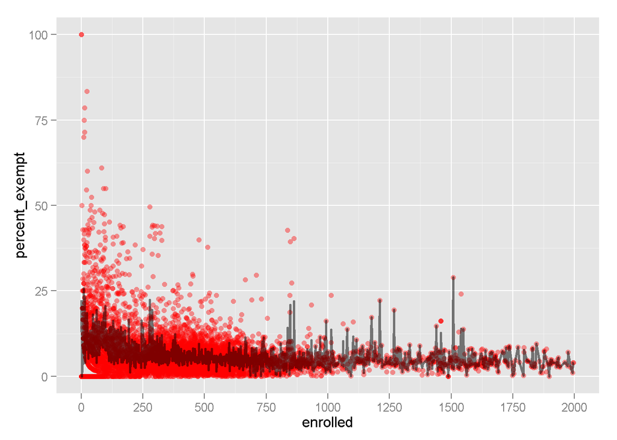

Mean percent exempt has high variance at low levels of enrollment. This make sense, since a small change in exemptions represents a larger proportion of the population vs. schools with higher levels of enrollment.

```
## geom_smooth: method="auto" and size of largest group is >=1000, so using gam with formula: y ~ s(x, bs = "cs"). Use 'method = x' to change the smoothing method.
```

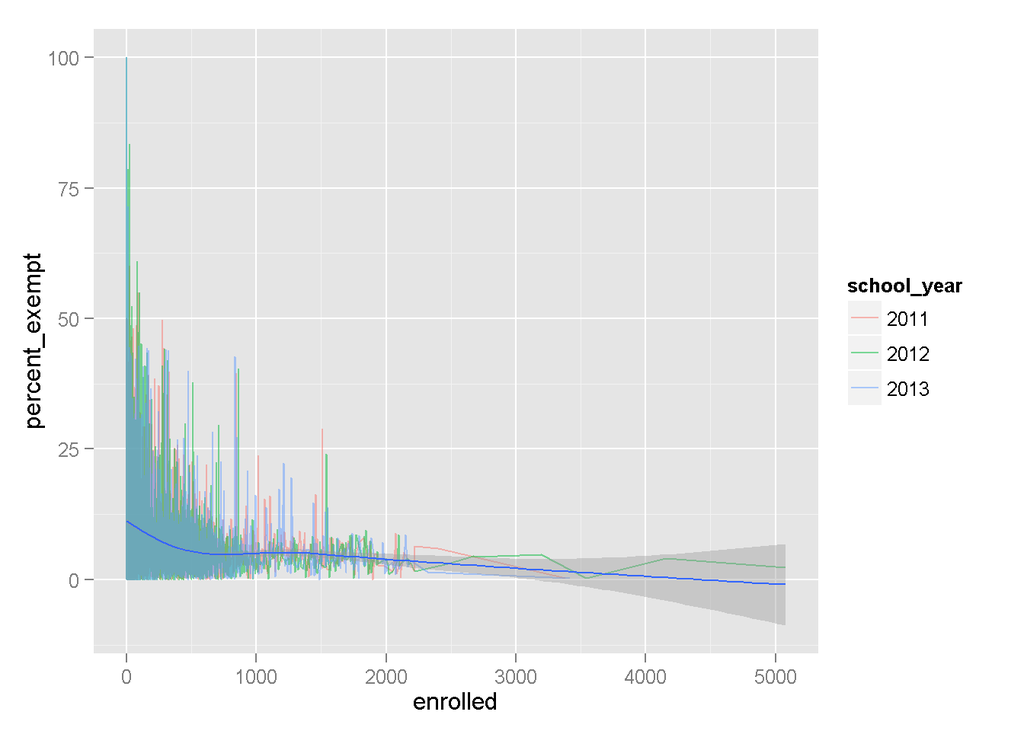

```
## geom_smooth: method="auto" and size of largest group is >=1000, so using gam with formula: y ~ s(x, bs = "cs"). Use 'method = x' to change the smoothing method.
```

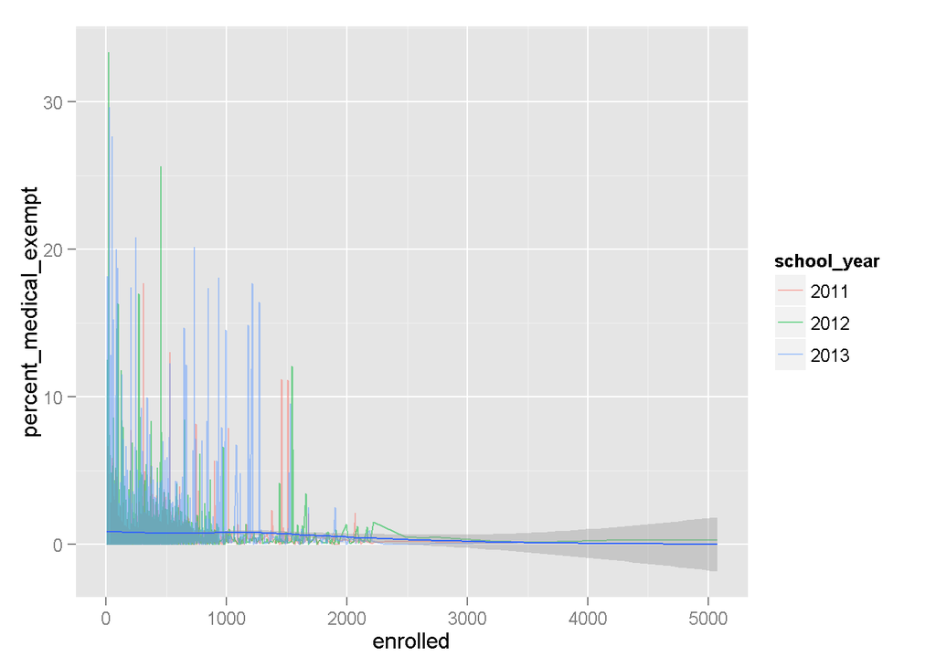

```
## geom_smooth: method="auto" and size of largest group is >=1000, so using gam with formula: y ~ s(x, bs = "cs"). Use 'method = x' to change the smoothing method.
```

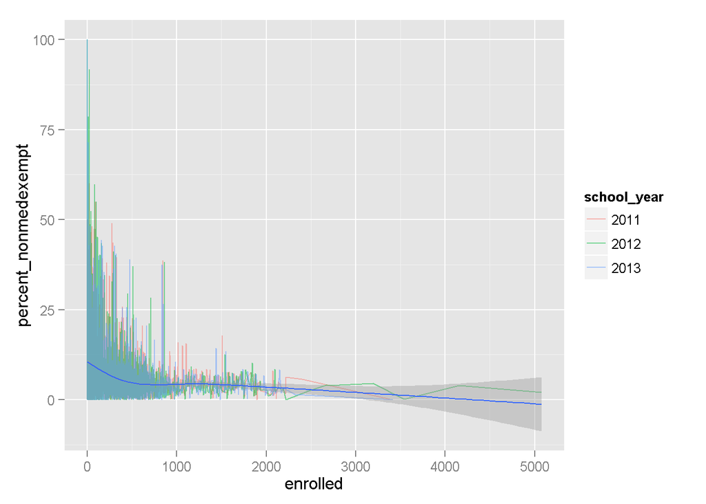

Percent exemption both general and specifc is largely flat across enrollment.

## Exemption rates vs. total exemptions

```
## geom_smooth: method="auto" and size of largest group is >=1000, so using gam with formula: y ~ s(x, bs = "cs"). Use 'method = x' to change the smoothing method.
```

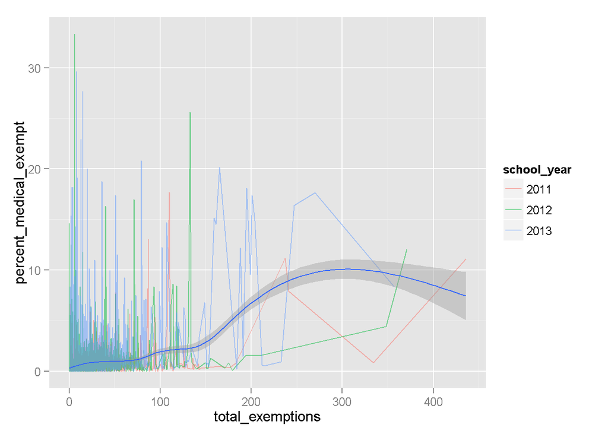

```
## geom_smooth: method="auto" and size of largest group is >=1000, so using gam with formula: y ~ s(x, bs = "cs"). Use 'method = x' to change the smoothing method.
```

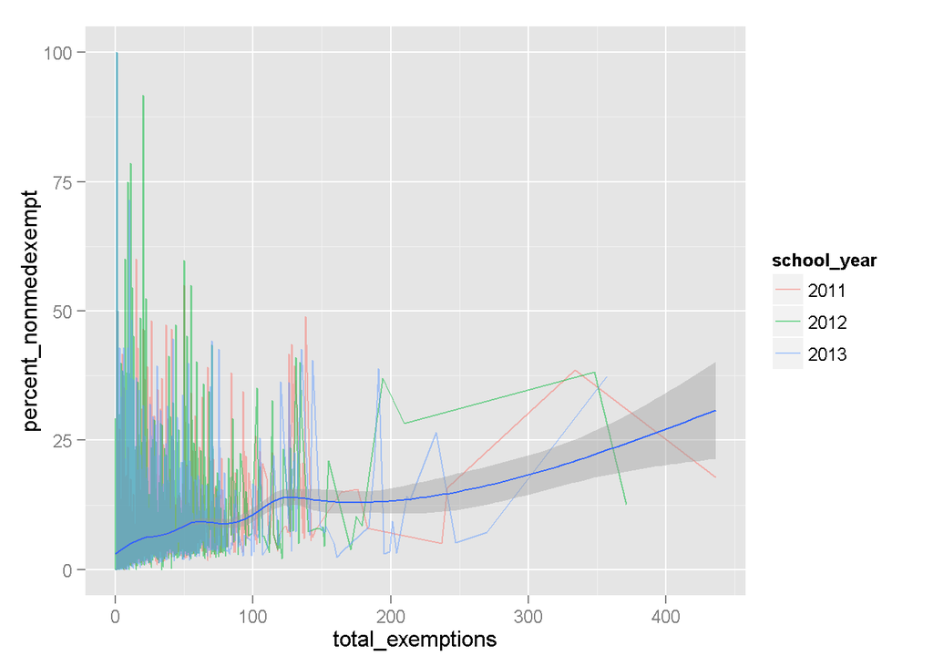

```
## geom_smooth: method="auto" and size of largest group is >=1000, so using gam with formula: y ~ s(x, bs = "cs"). Use 'method = x' to change the smoothing method.
```

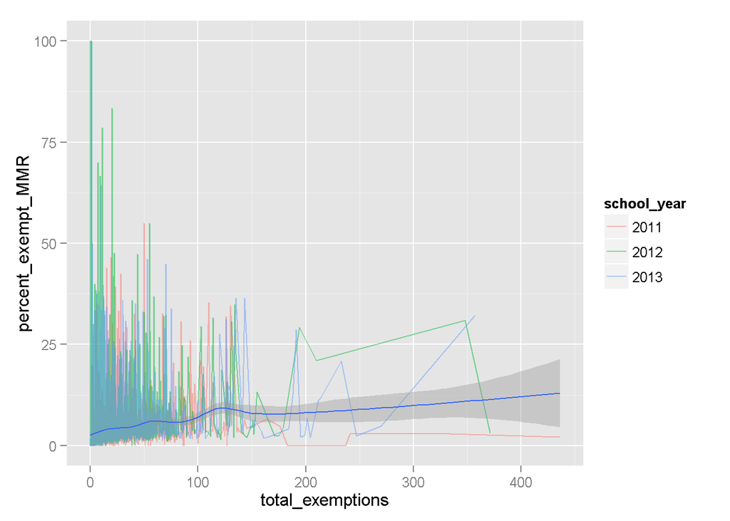

```
##
##  Pearson's product-moment correlation
##
## data:  vaccReported$total_exemptions and vaccReported$percent_exempt
## t = 29.4422, df = 6694, p-value < 2.2e-16
## alternative hypothesis: true correlation is not equal to 0
## 95 percent confidence interval:
##  0.3172190 0.3596349
## sample estimates:
##      cor
## 0.338599
```

```
##
##  Pearson's product-moment correlation
##
## data:  vaccReported$total_exemptions and vaccReported$percent_medical_exempt
## t = 23.5303, df = 6694, p-value < 2.2e-16
## alternative hypothesis: true correlation is not equal to 0
## 95 percent confidence interval:
##  0.2541234 0.2983711
## sample estimates:
##       cor
## 0.2763937
```

```
##
##  Pearson's product-moment correlation
##
## data:  vaccReported$total_exemptions and vaccReported$percent_nonmedexempt
## t = 24.2471, df = 6694, p-value < 2.2e-16
## alternative hypothesis: true correlation is not equal to 0
## 95 percent confidence interval:
##  0.2619730 0.3060127
## sample estimates:
##       cor
## 0.2841427
```

```
##
##  Pearson's product-moment correlation
##
## data:  vaccReported$total_exemptions and vaccReported$percent_exempt_MMR
## t = 14.6517, df = 6694, p-value < 2.2e-16
## alternative hypothesis: true correlation is not equal to 0
## 95 percent confidence interval:
##  0.1529677 0.1993854
## sample estimates:
##       cor
## 0.1762745
```

Weak positive correlation between total exemptions and both total and specific exemption types. Medical and non-medical exempt have ~ the same correlation to total exemptions.

## Specific exemptions vs. enrollment

```
## geom_smooth: method="auto" and size of largest group is >=1000, so using gam with formula: y ~ s(x, bs = "cs"). Use 'method = x' to change the smoothing method.
```

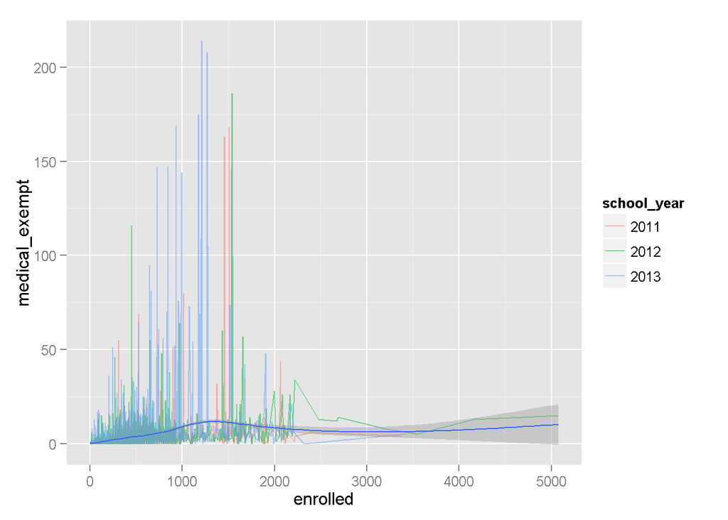

```
## geom_smooth: method="auto" and size of largest group is >=1000, so using gam with formula: y ~ s(x, bs = "cs"). Use 'method = x' to change the smoothing method.
```

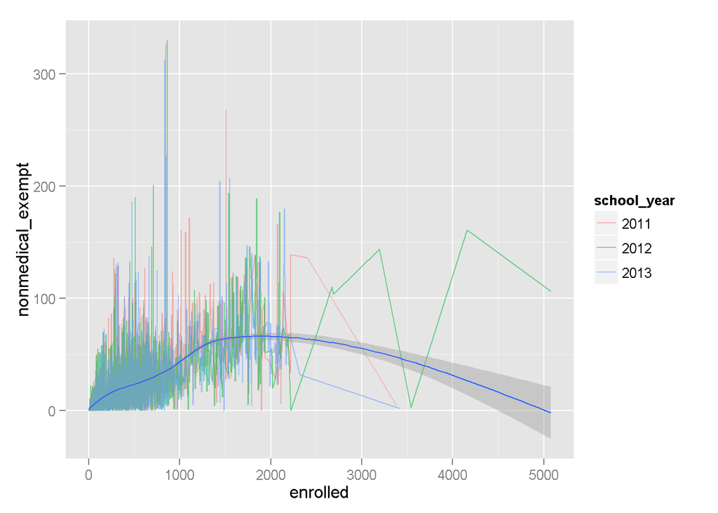

```
## geom_smooth: method="auto" and size of largest group is >=1000, so using gam with formula: y ~ s(x, bs = "cs"). Use 'method = x' to change the smoothing method.
```

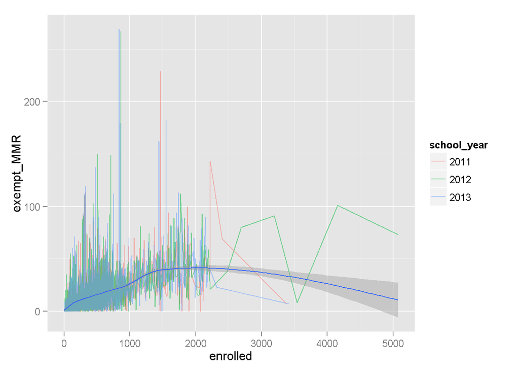

```
##
##  Pearson's product-moment correlation
##
## data:  vaccReported$enrolled and vaccReported$nonmedical_exempt
## t = 52.0693, df = 6694, p-value < 2.2e-16
## alternative hypothesis: true correlation is not equal to 0
## 95 percent confidence interval:
##  0.5196347 0.5537363
## sample estimates:
##       cor
## 0.5369048
```

[output not shown]

## Specific exemptions vs. total exemptions

```
## geom_smooth: method="auto" and size of largest group is >=1000, so using gam with formula: y ~ s(x, bs = "cs"). Use 'method = x' to change the smoothing method.
```

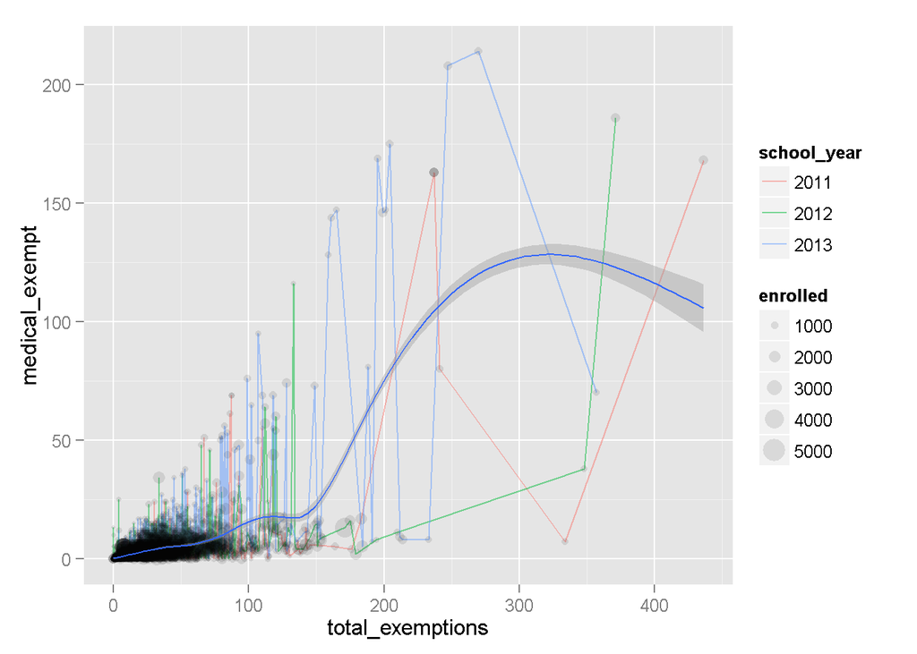

```
## geom_smooth: method="auto" and size of largest group is >=1000, so using gam with formula: y ~ s(x, bs = "cs"). Use 'method = x' to change the smoothing method.
```

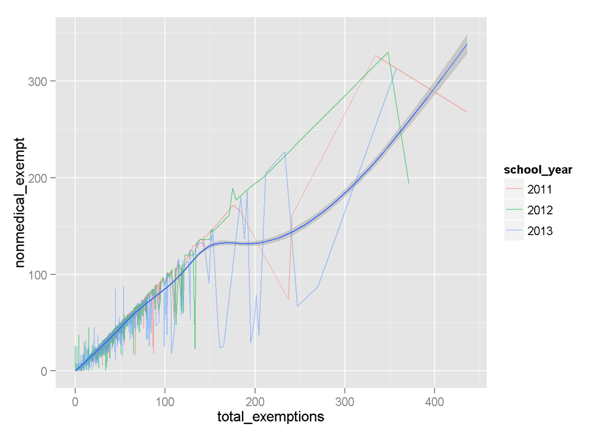

```
## geom_smooth: method="auto" and size of largest group is >=1000, so using gam with formula: y ~ s(x, bs = "cs"). Use 'method = x' to change the smoothing method.
```

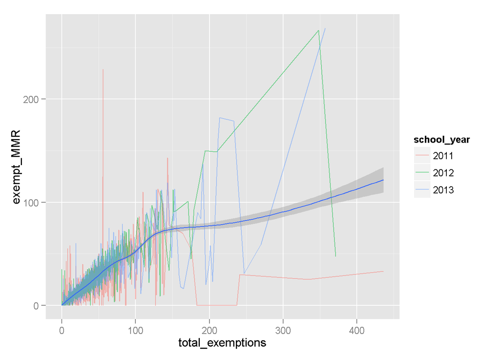

There is an interesting relationship between total exemptions and medical exemptions. The correlation is weak up to about 150 exemptions and then takes off, becoming negative at about 300 exemptions. Some of this is because there a very few schools beyond 150 exemptions, but note by the point size that this does not track strictly to school size (number of enrolled students).

There is a strong positive correlation between total exemptions and non-medical exemptions. The is also a strong positive correlation between total exemptions and MMR exemptions, but not as strong as non-medical exemptions.

## Specific exemption rates vs. total exemption rate

```
## geom_smooth: method="auto" and size of largest group is >=1000, so using gam with formula: y ~ s(x, bs = "cs"). Use 'method = x' to change the smoothing method.
```

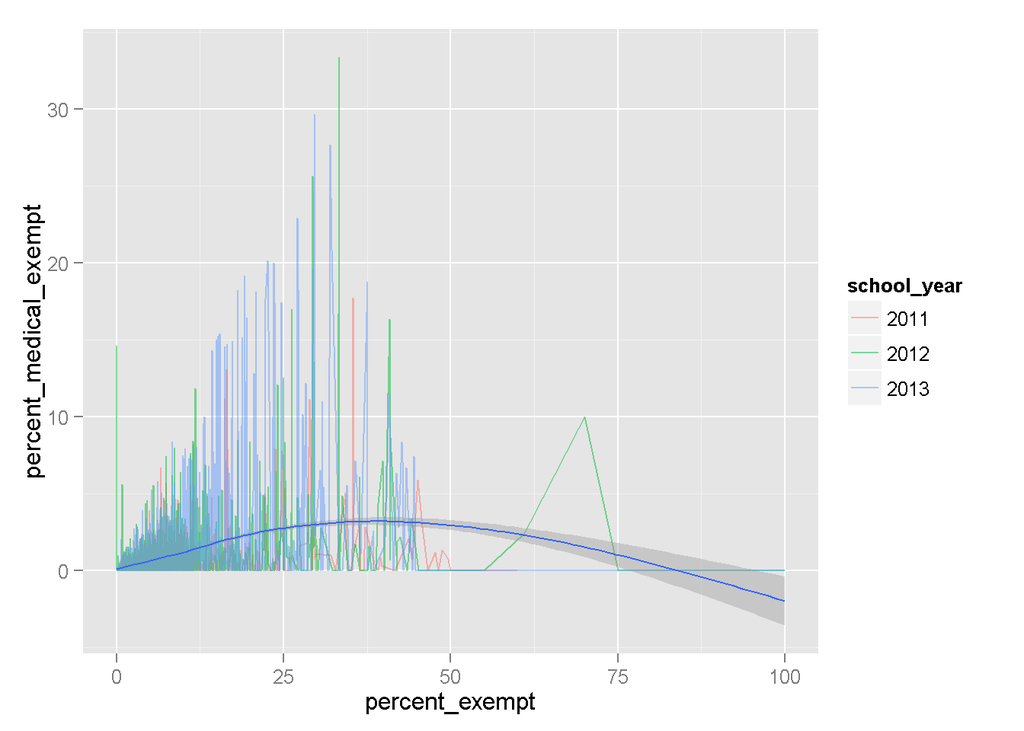

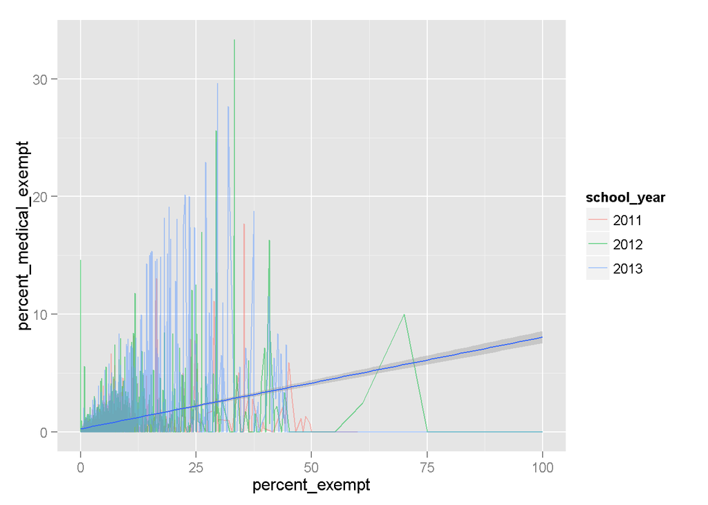

```
## geom_smooth: method="auto" and size of largest group is >=1000, so using gam with formula: y ~ s(x, bs = "cs"). Use 'method = x' to change the smoothing method.
```

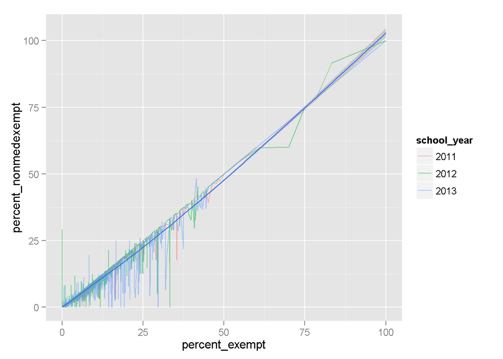

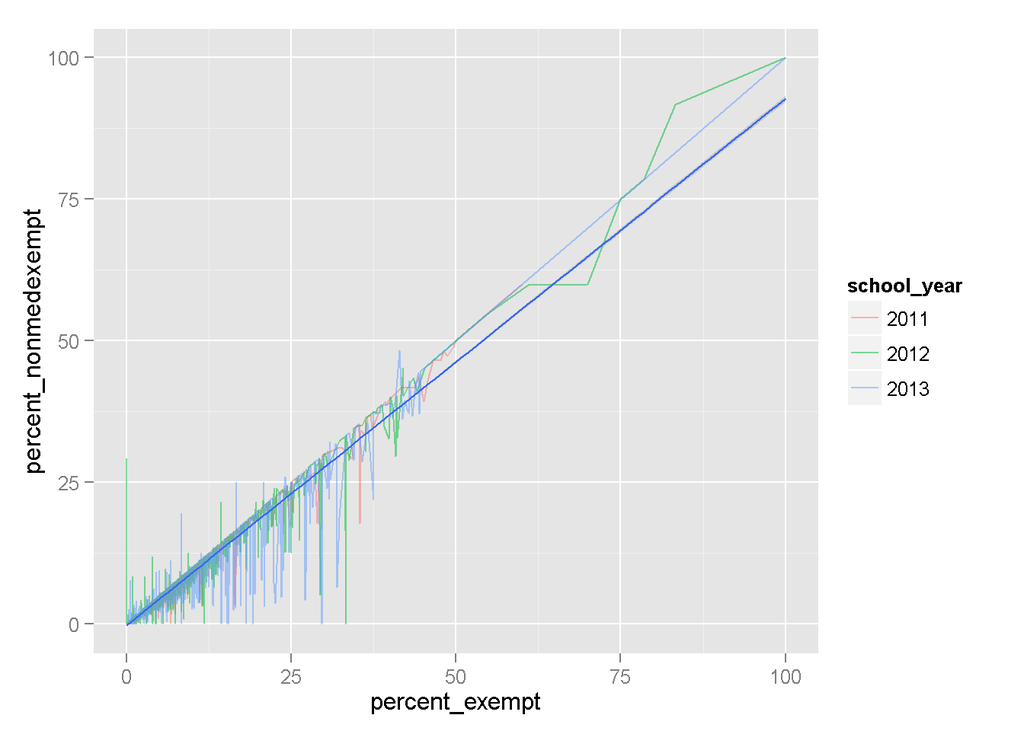

```
##
## Call:
## lm(formula = percent_nonmedexempt ~ percent_exempt, data = vaccReported)
##
## Coefficients:
##    (Intercept)  percent_exempt
##        -0.2264          0.9300
```

```
## geom_smooth: method="auto" and size of largest group is >=1000, so using gam with formula: y ~ s(x, bs = "cs"). Use 'method = x' to change the smoothing method.
```

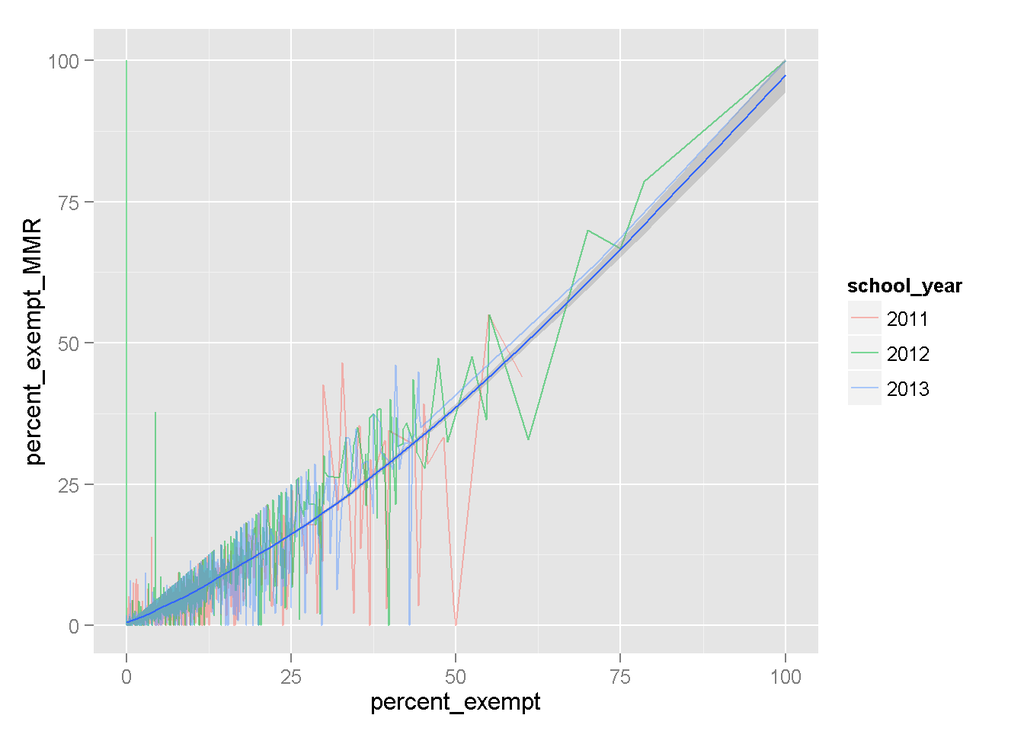

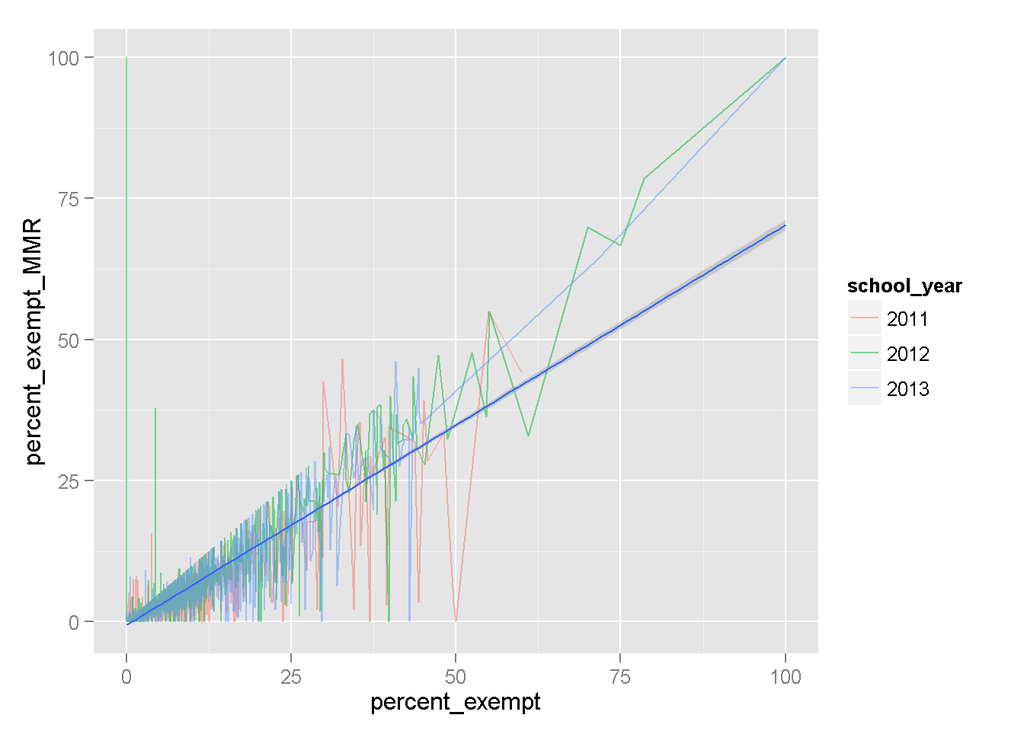

```
##
## Call:
## lm(formula = percent_exempt_MMR ~ percent_exempt, data = vaccReported)
##
## Coefficients:
##    (Intercept)  percent_exempt
##        -0.5163          0.7083
```

Showing code here for sake of clarity. Calculating predicted MMR rate and non-medical exempt rate using linear fit.

```r
# function to solve for y in y = mx + b, for a given x
lm_y <- function(lin, x) {
  m = coef(lin)[2]
  b = coef(lin)[1]
  return((m*x) + b)

}


lm_y(linear_MMR_rate,10)
```

```
## percent_exempt
##       6.566816
```

```r
lm_y(linear_nonmed_rate,10)
```

```
## percent_exempt
##       9.074078
```

```r
# function to solve for x in y = mx + b, for a given x
lm_x <- function(lin, y) {
  m = coef(lin)[2]
  b = coef(lin)[1]
  return((y-b)/m)

}

#solve lm predicted total exemption rate for a 5% MMR exemption rate
lm_x(linear_MMR_rate,5)
```

```
## (Intercept)
##    7.787952
```

Medical exemption rates show a weak positive correlation to total exemption rates. Both non-medical and MMR exemptions show a strong positive correlation to total exemption rates.

## Analyzing the grouped data

Grouped data per above used for the following sections.

## Exemptions by school year

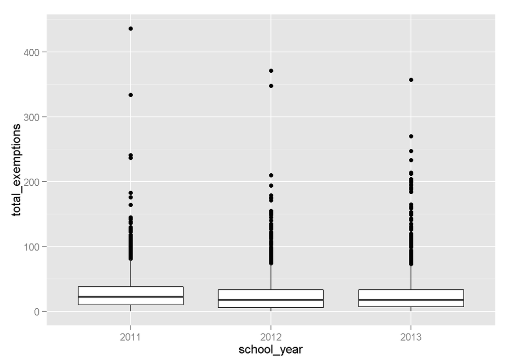

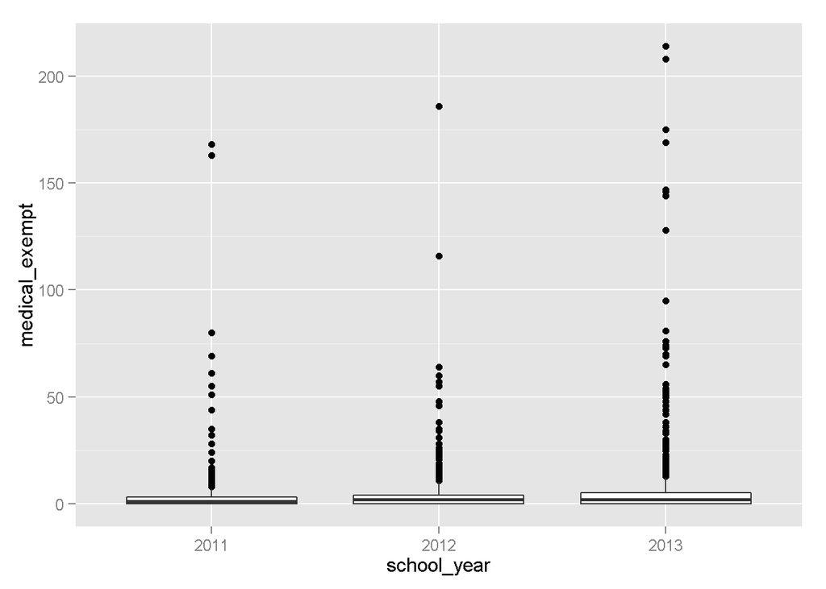

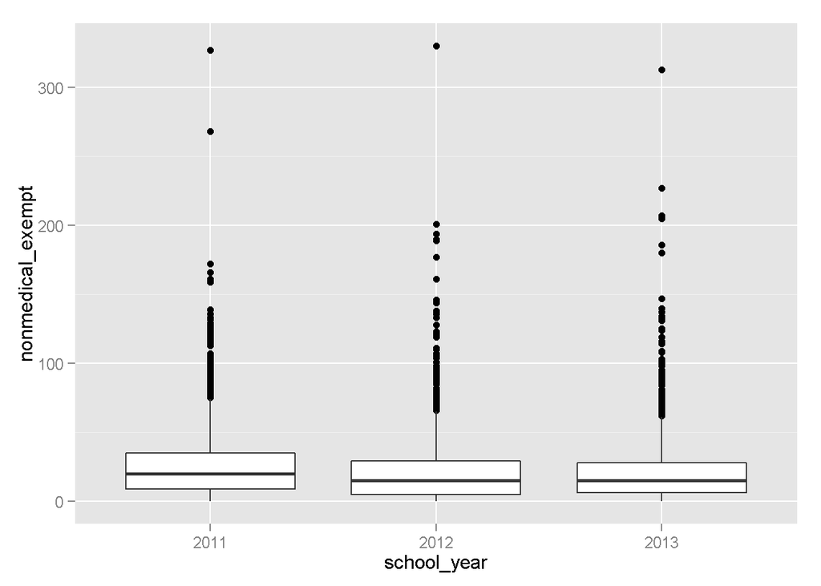

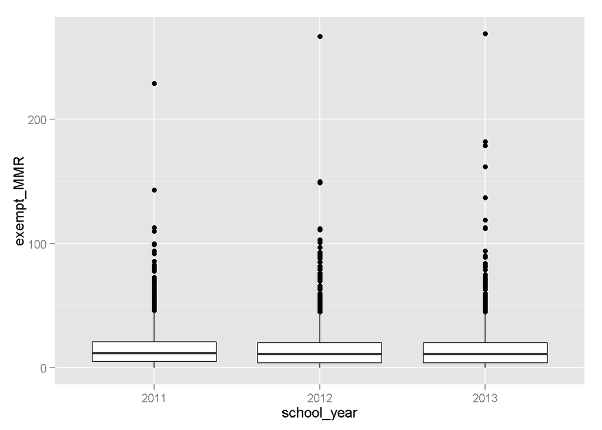

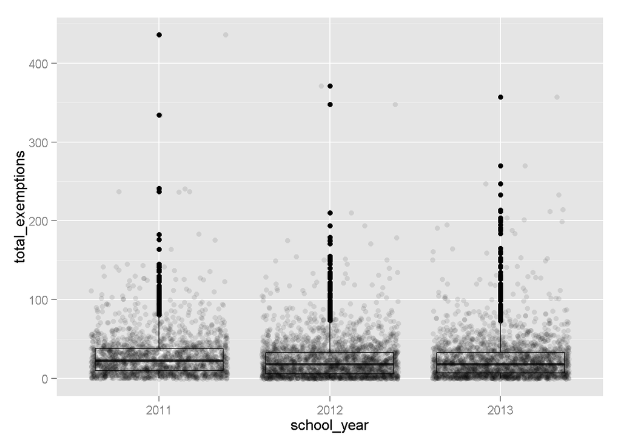

Except for the astounding number of outliers, there is not much to see from year to year, please move along.

## Exemptions by school type

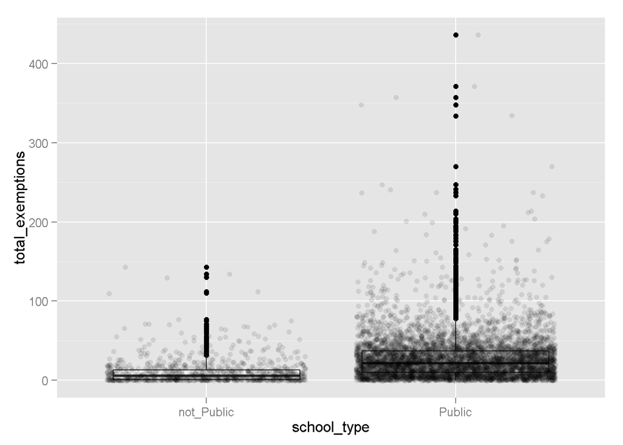

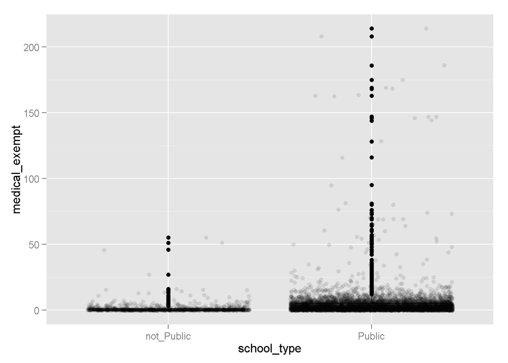

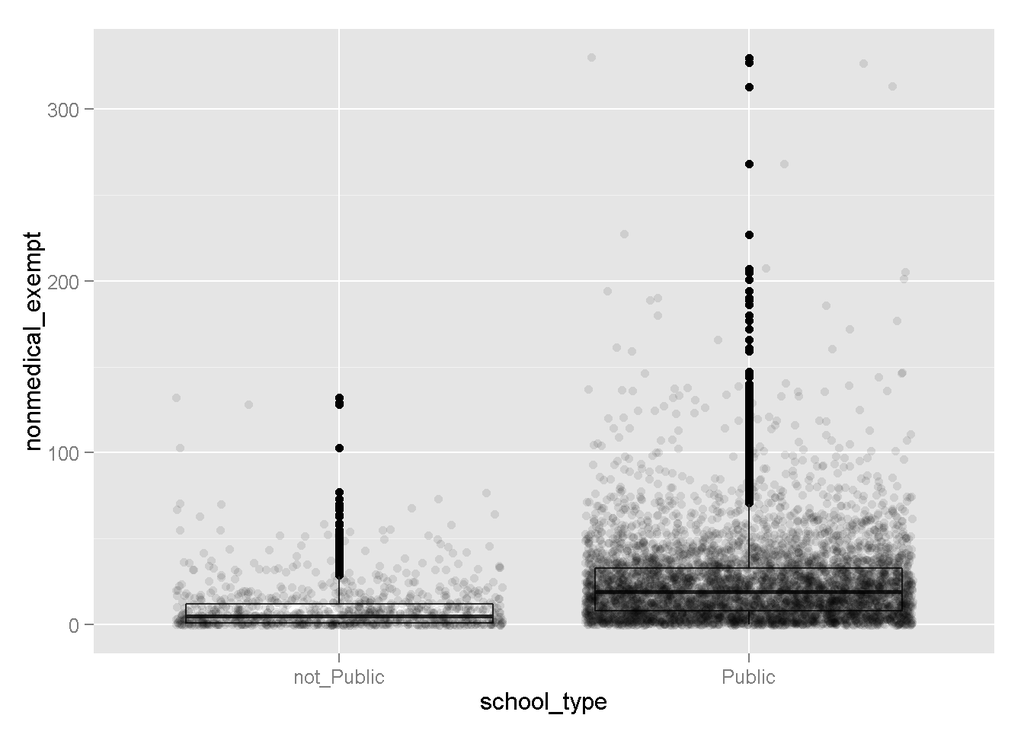

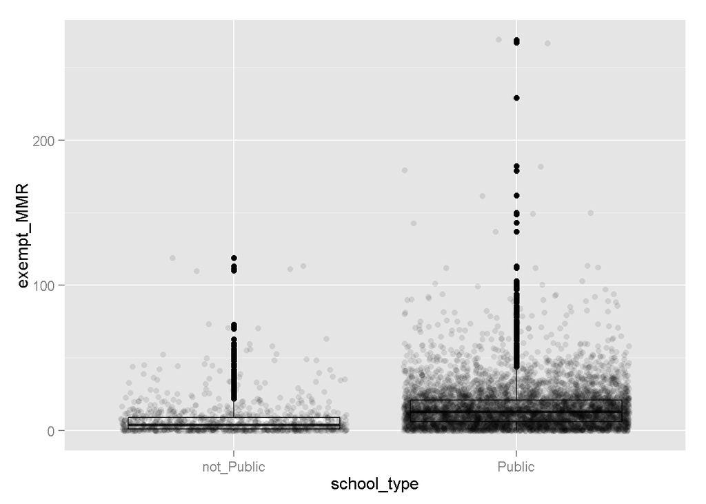

Public shcools have a higher median and larger spread of total exemptions, non-medical exemptions, and MMR exemptions. The spread is very tight for medical exemptions, with comparable medians. Some of the variability in the public schools can be explained by the fact that public schools have a larger range of enrolled students. However, this doesn’t explain observations for medical exemptions.

## Exemption rates by school year

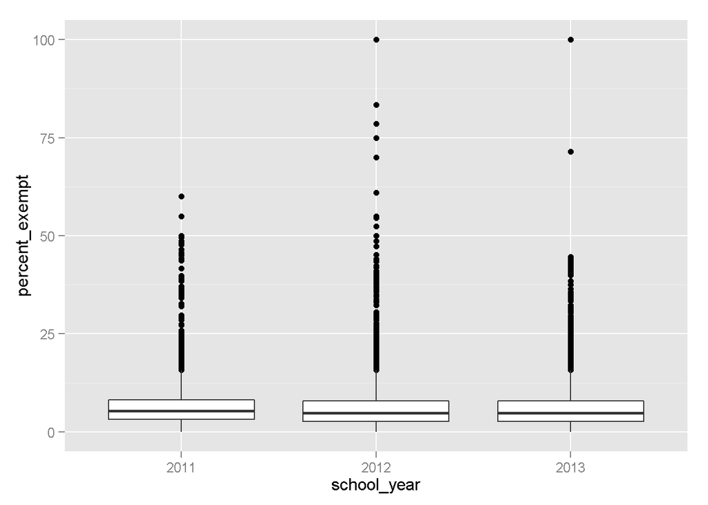

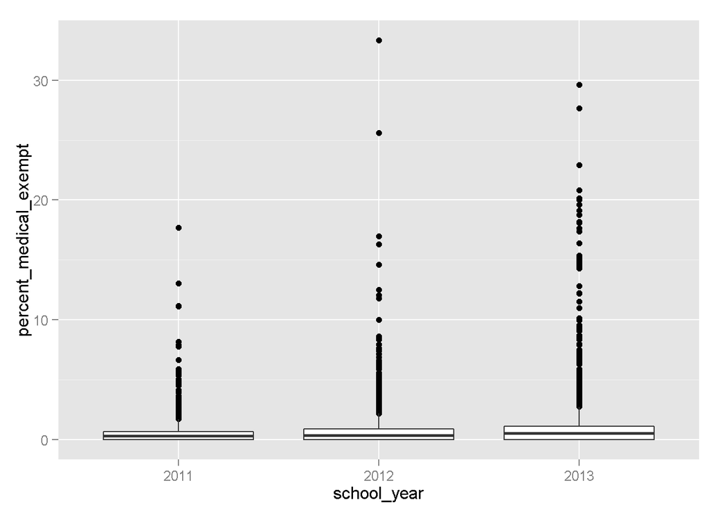

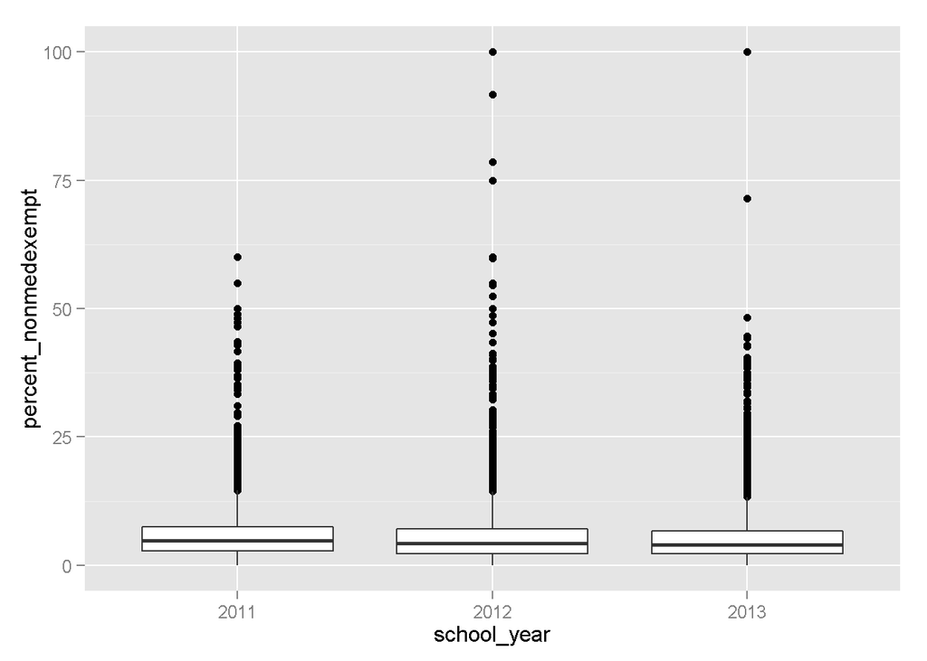

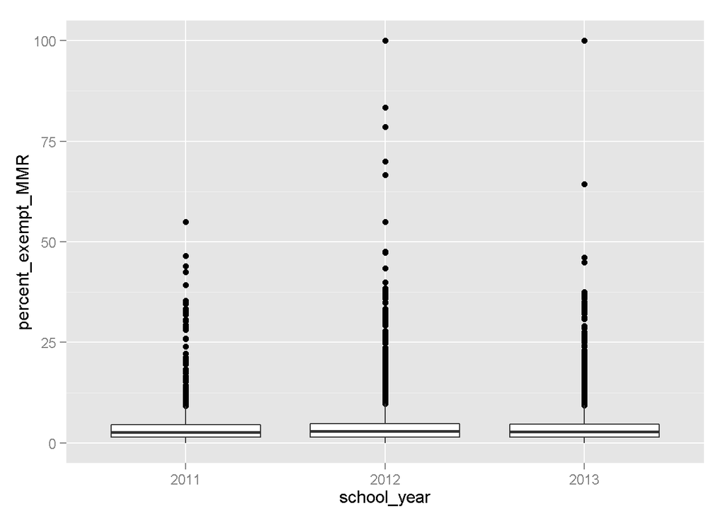

Second verse same as the first.

## Exemption rates by school type

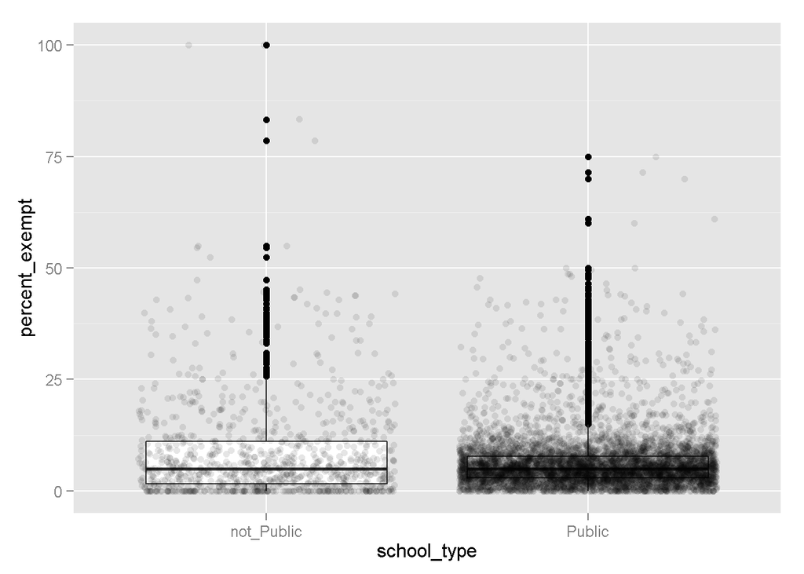

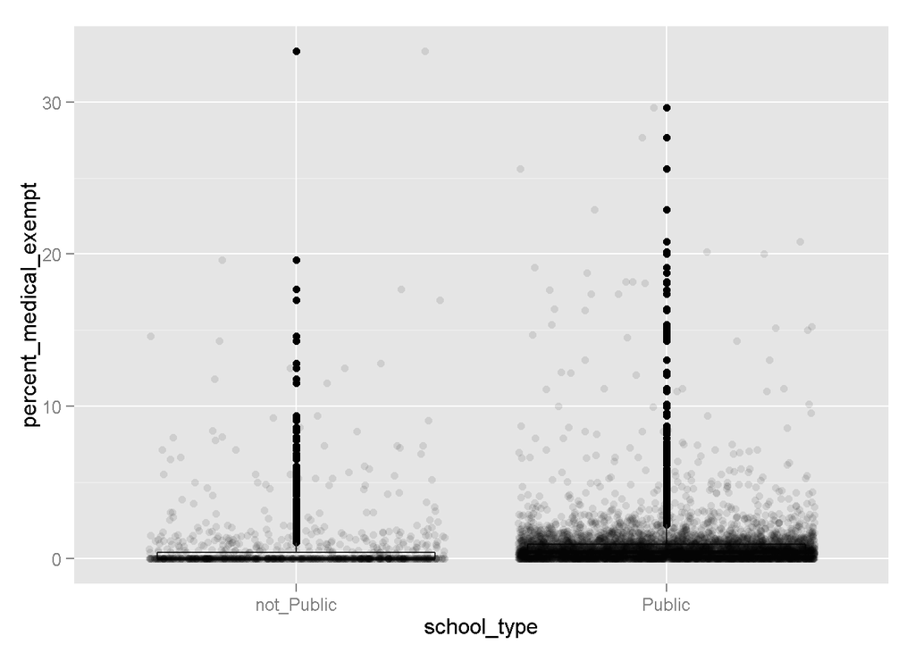

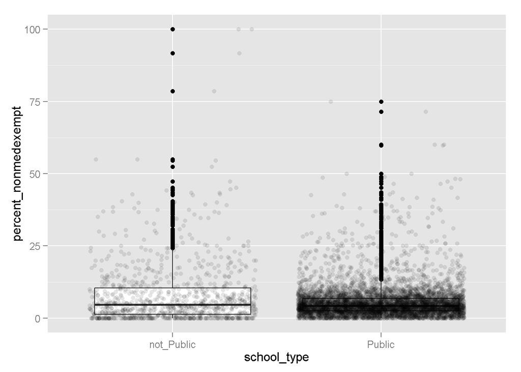

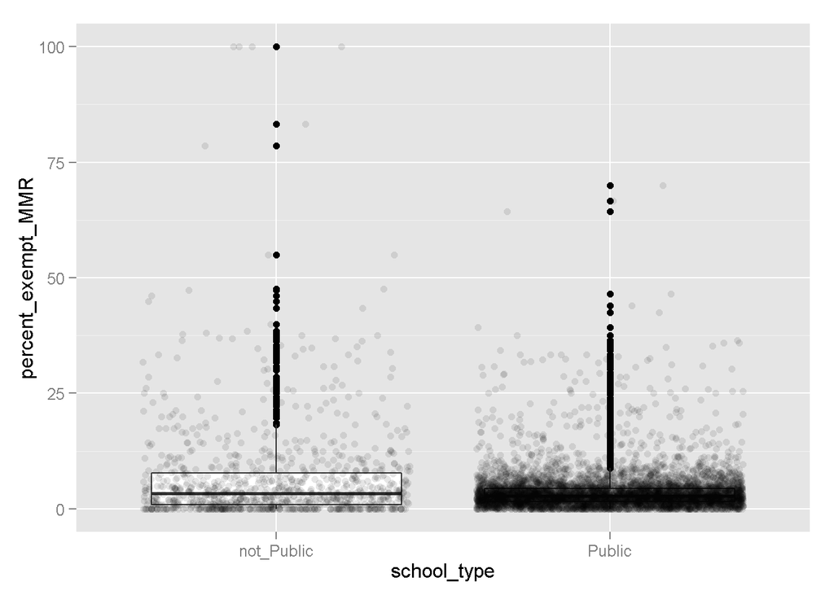

This is interesting to me. The median level is about the same for public vs. private (not-public) but the spread is much greater or private. I’ve looked at analyses from other states that essentially show that not all private schools, even by type of private school (Waldorf, Montessori) are created equal in terms of vaccination attitudes (tendency towards personal/non-medical exemptions). I don’t know if this is true of my data set, but there seems to be more variability in private vs. public schools. These plots suggest this is true of non-medical and MMR exemptions, but not medical exemptions.

```
## geom_smooth: method="auto" and size of largest group is >=1000, so using gam with formula: y ~ s(x, bs = "cs"). Use 'method = x' to change the smoothing method.
```

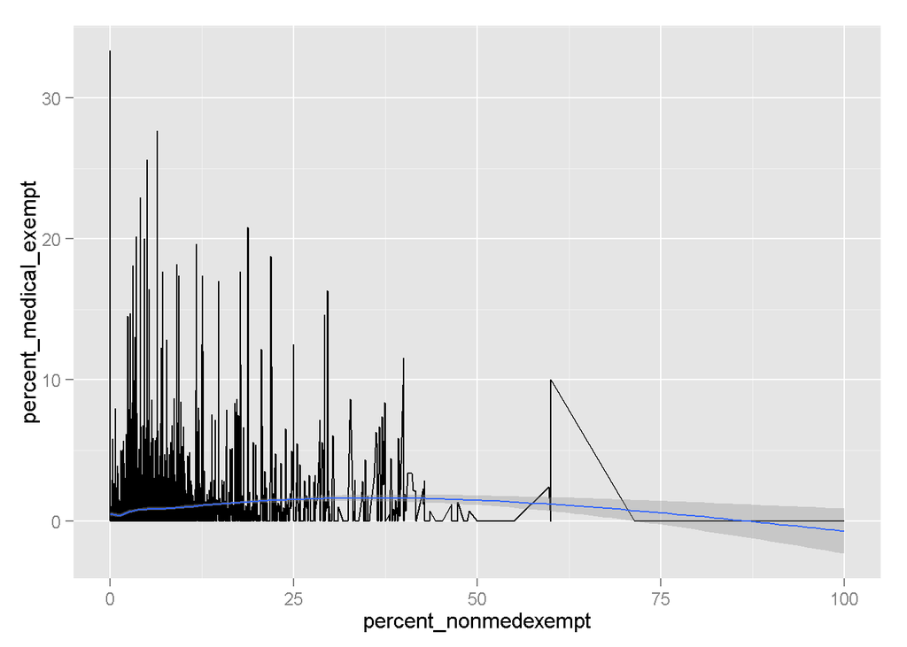

```
## geom_smooth: method="auto" and size of largest group is >=1000, so using gam with formula: y ~ s(x, bs = "cs"). Use 'method = x' to change the smoothing method.
```

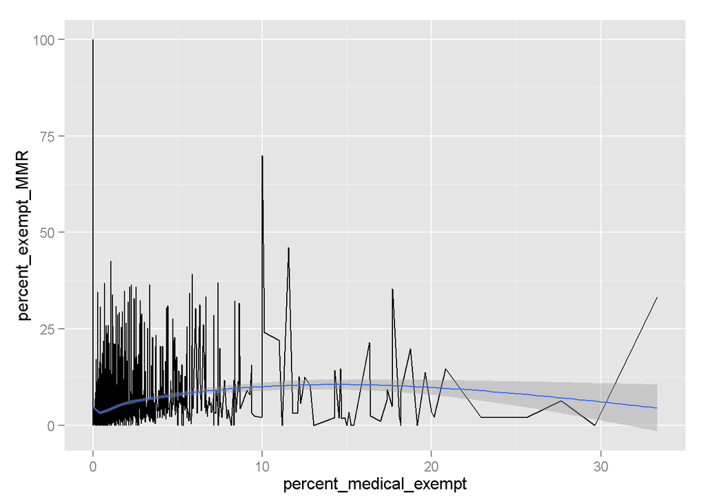

```
## geom_smooth: method="auto" and size of largest group is >=1000, so using gam with formula: y ~ s(x, bs = "cs"). Use 'method = x' to change the smoothing method.
```

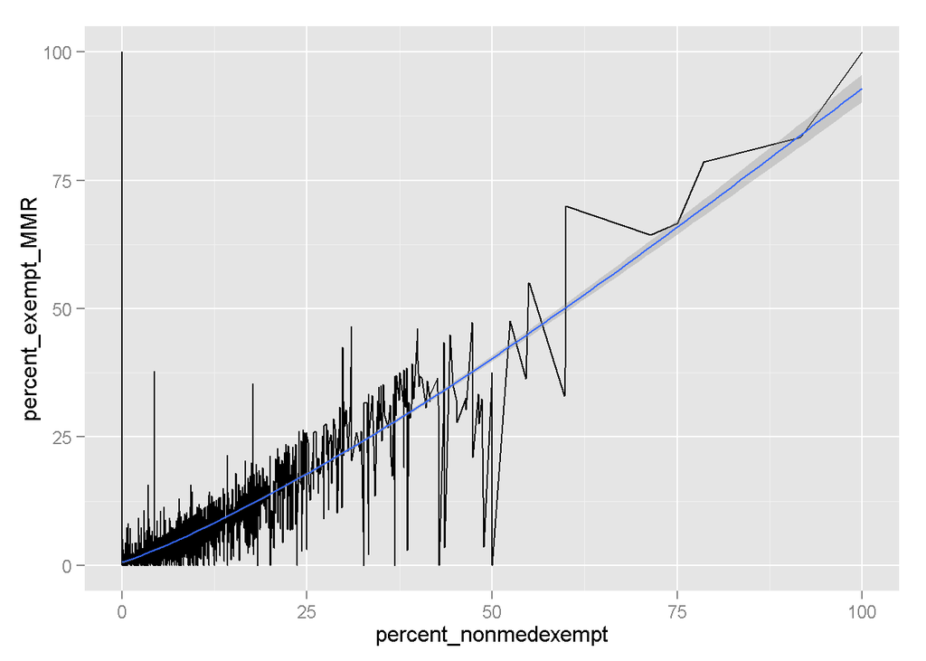

Medical and non-medical exemption rates or MMR exemption rates do not have a strong relationship. Non-medical exemption rates and MMR exemption rates have strong positive relationship.

# Bivariate Analysis

### Did you observe any interesting relationships between the other features (not the main feature(s) of interest)?

The median level is about the same for public vs. private (not-public) but the spread is much greater for private. I’ve looked at analyses from other states that essentially show that not all private schools, even by type of private school (Waldorf, Montessori) are created equal in terms of vaccinations attitudes (tendency towards personal/non-medical exemptions). I don’t know if this is true of my data set, but there seems to be more variability in private vs. public schools. Plots suggest this is true of non-medical and MMR exemptions, but not medical exemptions.

### What was the strongest relationship you found?

- Non-medical exemption rates and total exemption rate and MMR exemption rates and non-medical exemption rates.

# Multivariate Plots Section

Technically some of the bivariate plots could be considred multivariate since rates are derivative of more than once variable. Below I try to understand whether relationships signifcantly as a function of year or school type. I also include some other visualizatons to help foster an understanding of the data.

## Rates vs. total exemptions, by year

```
## geom_smooth: method="auto" and size of largest group is >=1000, so using gam with formula: y ~ s(x, bs = "cs"). Use 'method = x' to change the smoothing method.
```

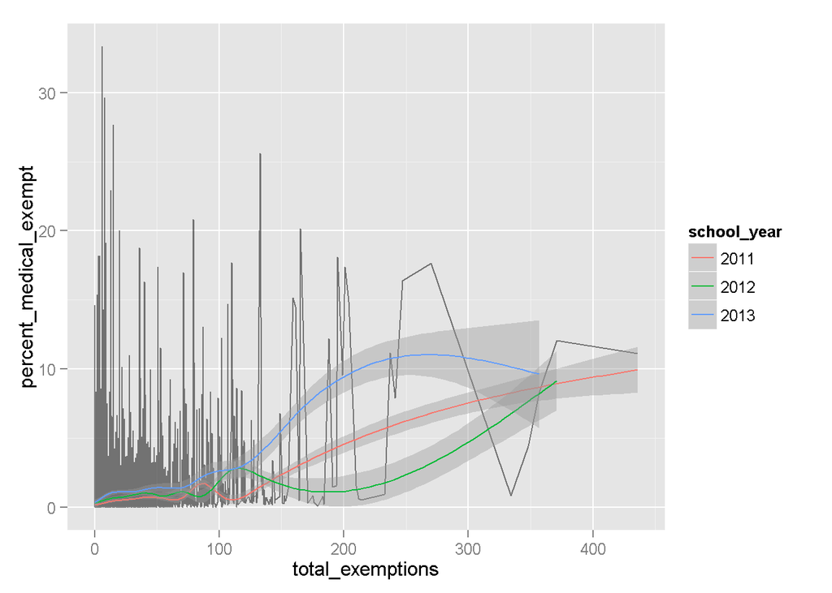

```
## geom_smooth: method="auto" and size of largest group is >=1000, so using gam with formula: y ~ s(x, bs = "cs"). Use 'method = x' to change the smoothing method.
```

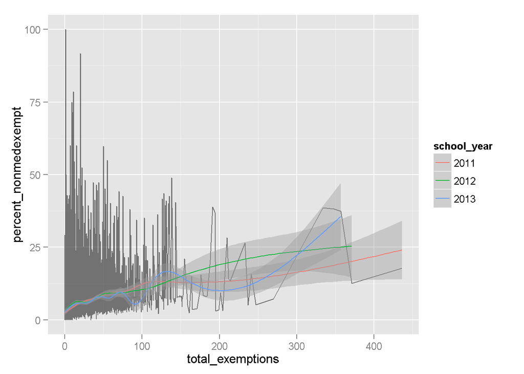

```
## geom_smooth: method="auto" and size of largest group is >=1000, so using gam with formula: y ~ s(x, bs = "cs"). Use 'method = x' to change the smoothing method.
```

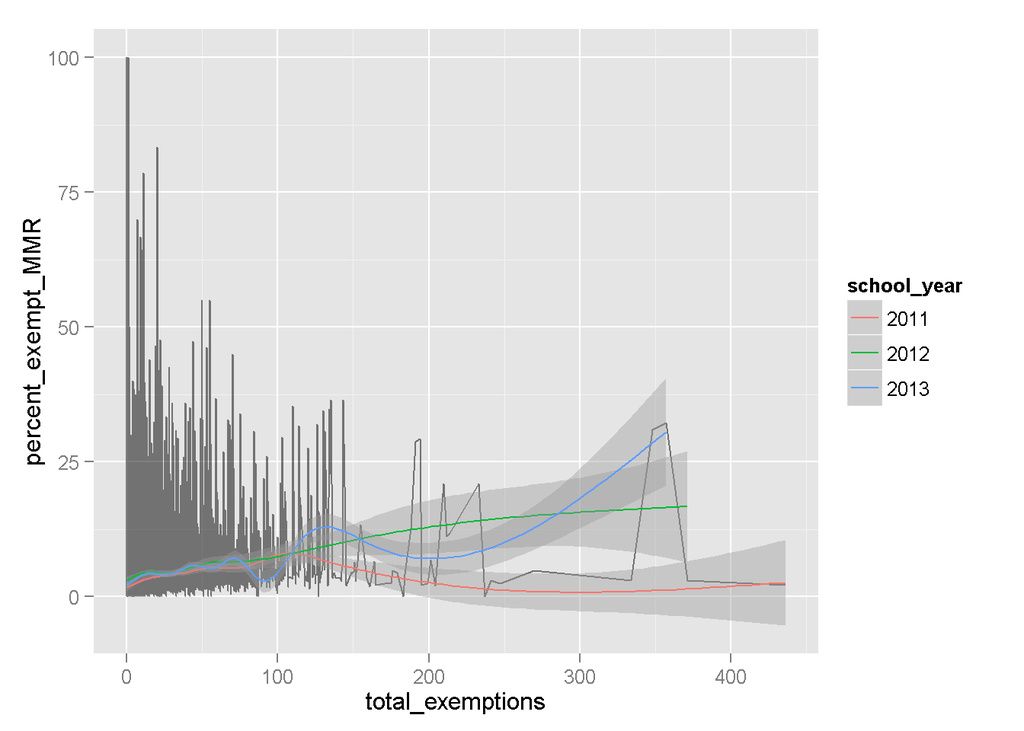

- Observing year to year variation, particularly beyond 100 total exemptions*

## Specific exemptions vs. total exemptions by school year and by school type

```
## geom_smooth: method="auto" and size of largest group is >=1000, so using gam with formula: y ~ s(x, bs = "cs"). Use 'method = x' to change the smoothing method.
```

```
## geom_smooth: method="auto" and size of largest group is >=1000, so using gam with formula: y ~ s(x, bs = "cs"). Use 'method = x' to change the smoothing method.
```

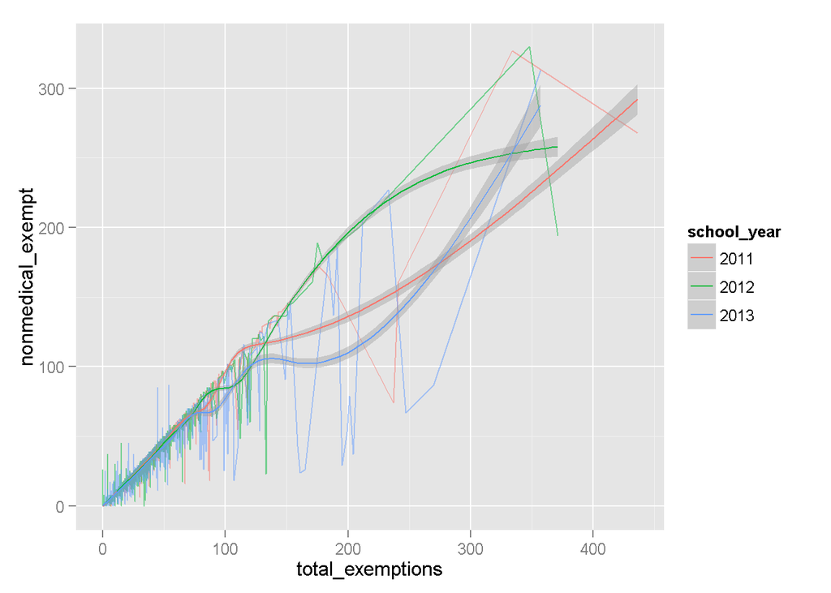

- Observing year to year variation, particularly beyond 100 total exemptions*

```
## geom_smooth: method="auto" and size of largest group is >=1000, so using gam with formula: y ~ s(x, bs = "cs"). Use 'method = x' to change the smoothing method.
```

```
## geom_smooth: method="auto" and size of largest group is >=1000, so using gam with formula: y ~ s(x, bs = "cs"). Use 'method = x' to change the smoothing method.
```

[figure not shown]

```
## geom_smooth: method="auto" and size of largest group is >=1000, so using gam with formula: y ~ s(x, bs = "cs"). Use 'method = x' to change the smoothing method.
```

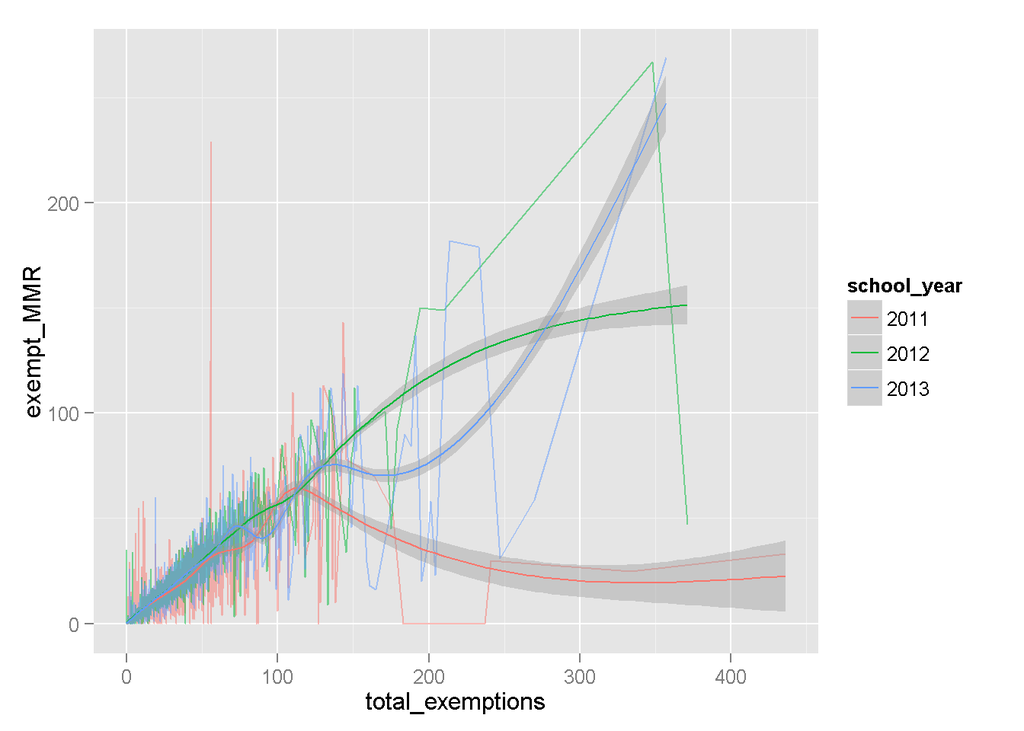

```
## geom_smooth: method="auto" and size of largest group is >=1000, so using gam with formula: y ~ s(x, bs = "cs"). Use 'method = x' to change the smoothing method.
```

```
## geom_smooth: method="auto" and size of largest group is >=1000, so using gam with formula: y ~ s(x, bs = "cs"). Use 'method = x' to change the smoothing method.
```

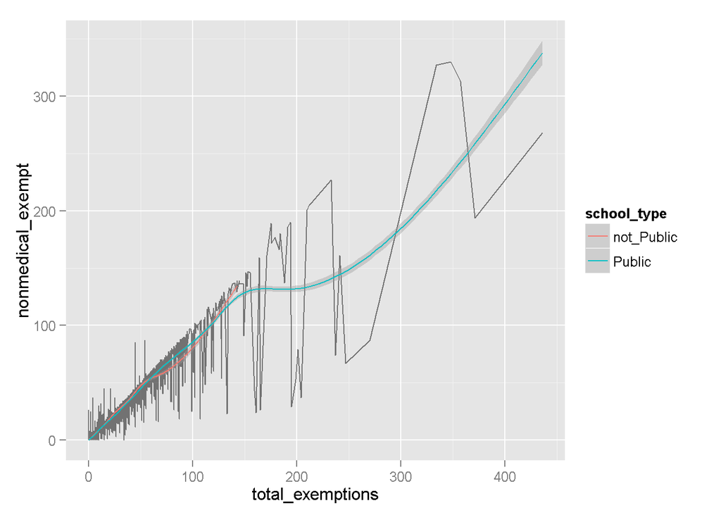

```
## geom_smooth: method="auto" and size of largest group is >=1000, so using gam with formula: y ~ s(x, bs = "cs"). Use 'method = x' to change the smoothing method.
```

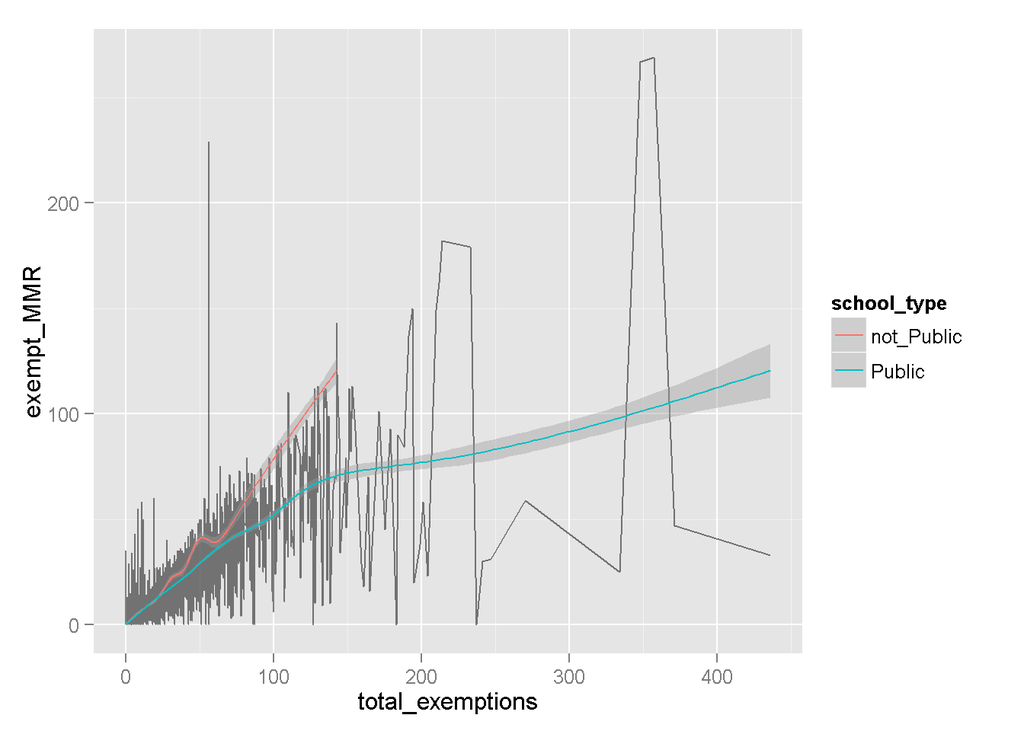

- Observing year to year variation, particularly beyond 100 total exemptions*
- observing little varition in non-medical exempt by type*
- observing a divergence in rate between public and private schools for MMR exemptions*

## Rate vs. rate by year

```
## geom_smooth: method="auto" and size of largest group is >=1000, so using gam with formula: y ~ s(x, bs = "cs"). Use 'method = x' to change the smoothing method.
```

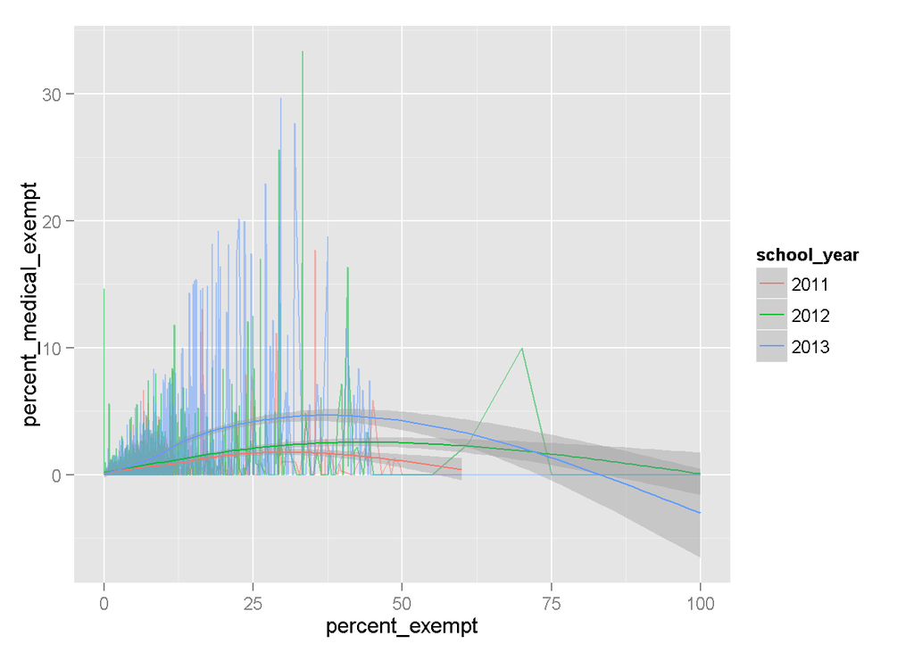

```
## geom_smooth: method="auto" and size of largest group is >=1000, so using gam with formula: y ~ s(x, bs = "cs"). Use 'method = x' to change the smoothing method.
```

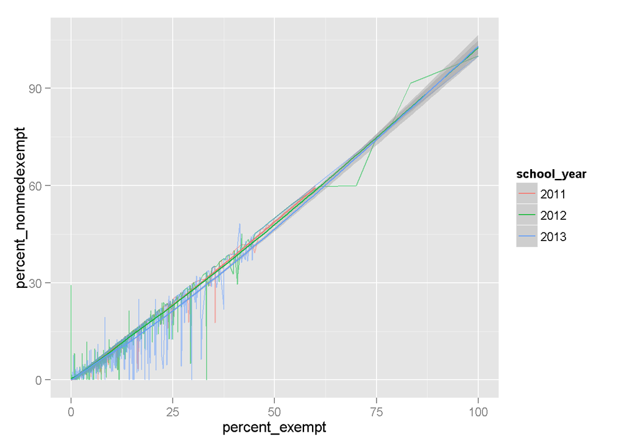

```
## geom_smooth: method="auto" and size of largest group is >=1000, so using gam with formula: y ~ s(x, bs = "cs"). Use 'method = x' to change the smoothing method.
```

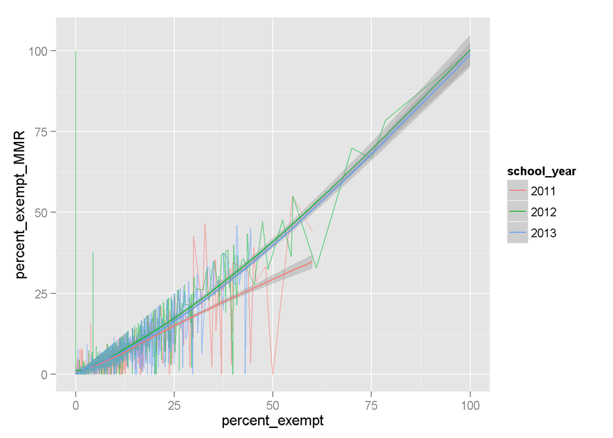

```
## geom_smooth: method="auto" and size of largest group is >=1000, so using gam with formula: y ~ s(x, bs = "cs"). Use 'method = x' to change the smoothing method.
## geom_smooth: method="auto" and size of largest group is >=1000, so using gam with formula: y ~ s(x, bs = "cs"). Use 'method = x' to change the smoothing method.
## geom_smooth: method="auto" and size of largest group is >=1000, so using gam with formula: y ~ s(x, bs = "cs"). Use 'method = x' to change the smoothing method.
```

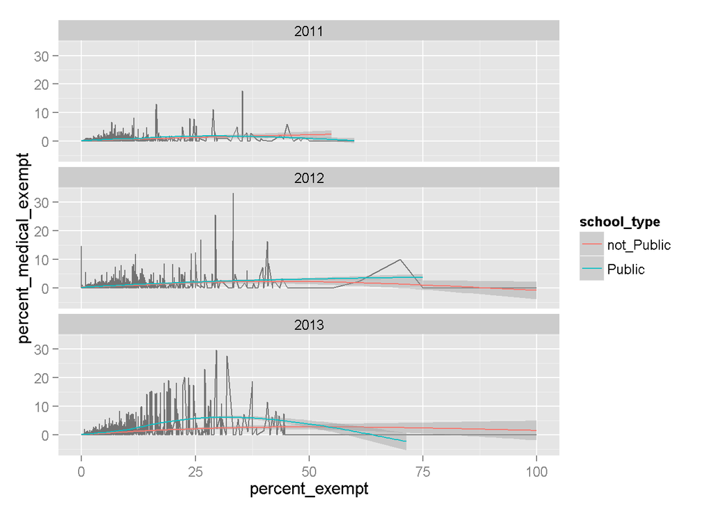

```
## geom_smooth: method="auto" and size of largest group is >=1000, so using gam with formula: y ~ s(x, bs = "cs"). Use 'method = x' to change the smoothing method.
## geom_smooth: method="auto" and size of largest group is >=1000, so using gam with formula: y ~ s(x, bs = "cs"). Use 'method = x' to change the smoothing method.
## geom_smooth: method="auto" and size of largest group is >=1000, so using gam with formula: y ~ s(x, bs = "cs"). Use 'method = x' to change the smoothing method.
```

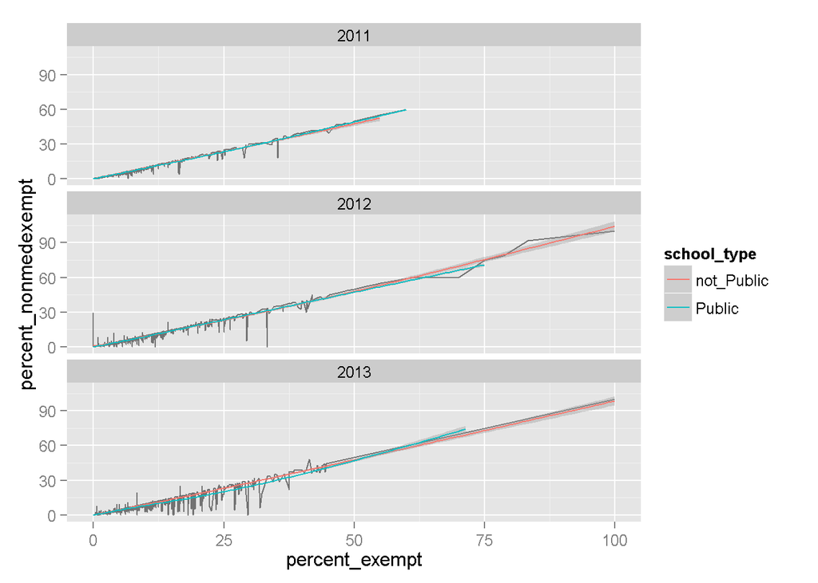

```
## geom_smooth: method="auto" and size of largest group is >=1000, so using gam with formula: y ~ s(x, bs = "cs"). Use 'method = x' to change the smoothing method.
## geom_smooth: method="auto" and size of largest group is >=1000, so using gam with formula: y ~ s(x, bs = "cs"). Use 'method = x' to change the smoothing method.
## geom_smooth: method="auto" and size of largest group is >=1000, so using gam with formula: y ~ s(x, bs = "cs"). Use 'method = x' to change the smoothing method.
```

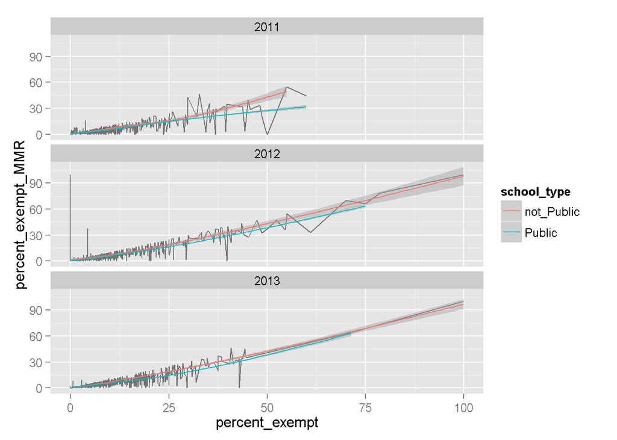

- observing minimal variation for percent non-medical exempt by year and school type*
- observing some variation for 2011 percent exempt MMR at ~ > 25% total exemptions by year*
- observing some variation for 2011 percent exempt MMR at ~ > 40% total exemptions by school type*

### Add 5 and 10% Vertical lines.

Added in vertical lines at 5 and 10% which is an estimate of the safety threshold for MMR and total exemption rates, respectively (see intro for further detail). This is for purposes of illustration.

```
## geom_smooth: method="auto" and size of largest group is >=1000, so using gam with formula: y ~ s(x, bs = "cs"). Use 'method = x' to change the smoothing method.
```

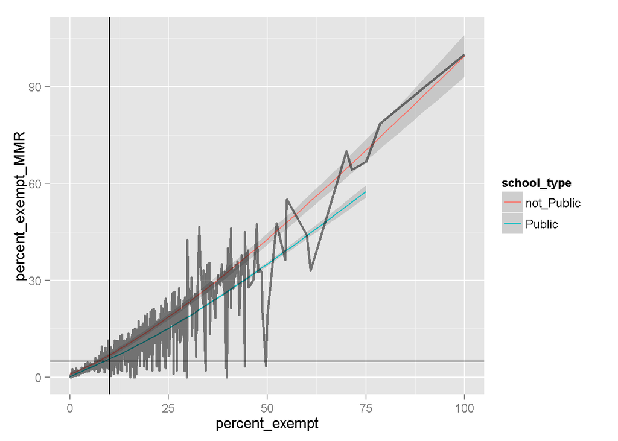

### Repeat on subset of vaccreported with enrollment of >=100 and <= 2500.

```
## geom_smooth: method="auto" and size of largest group is >=1000, so using gam with formula: y ~ s(x, bs = "cs"). Use 'method = x' to change the smoothing method.
```

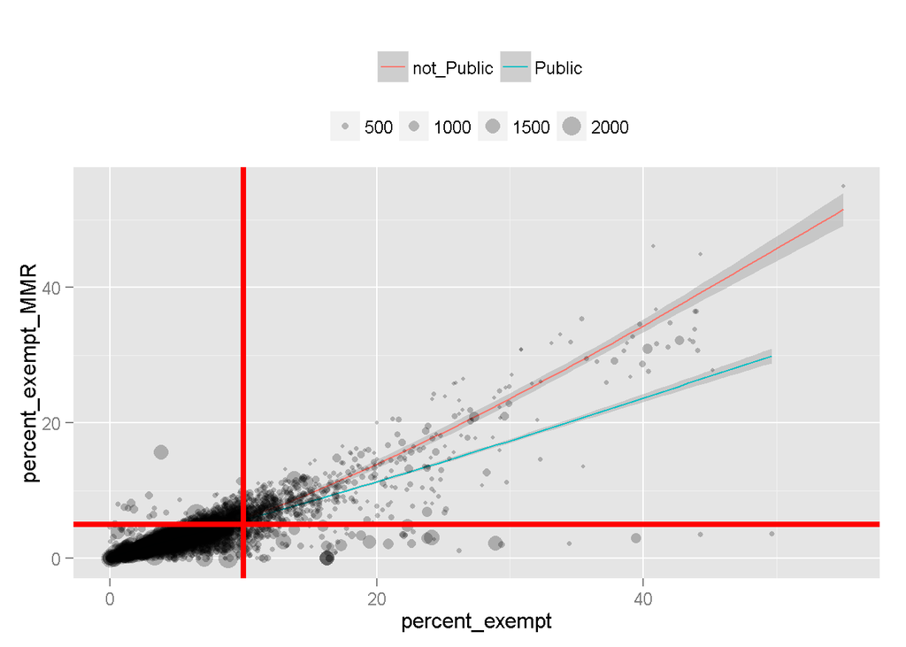

- The majority of the data falls below both thresholds*
- The school types start to diverge near the intersection of 5% MMR exemption rate and 10% total exemption rate*
- There is a subset of data that is above the MMR rate threshold but below the total exemption rate threshold*
- There is a subset of data that is below the MMR rate threshold but above the total exemption rate threshold*

## Bar Plots

Bar plots using the county_group and county_group_type data frames.

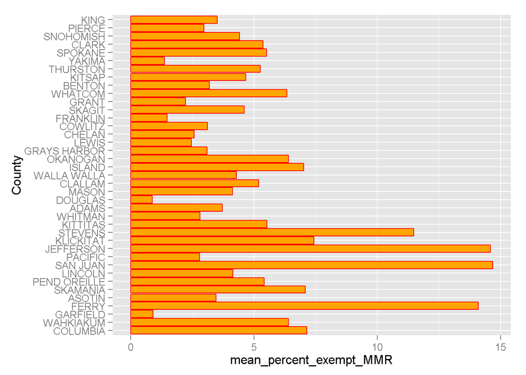

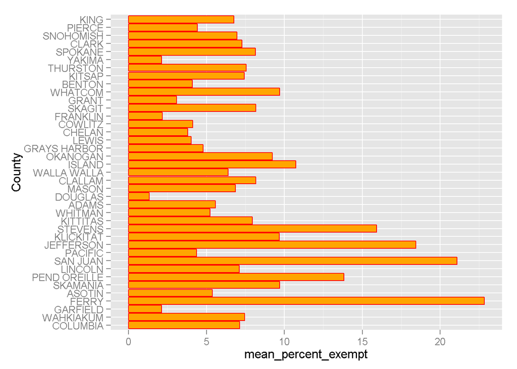

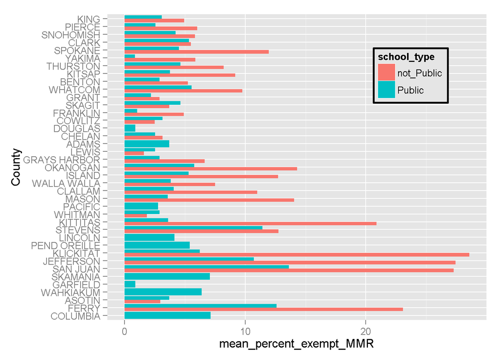

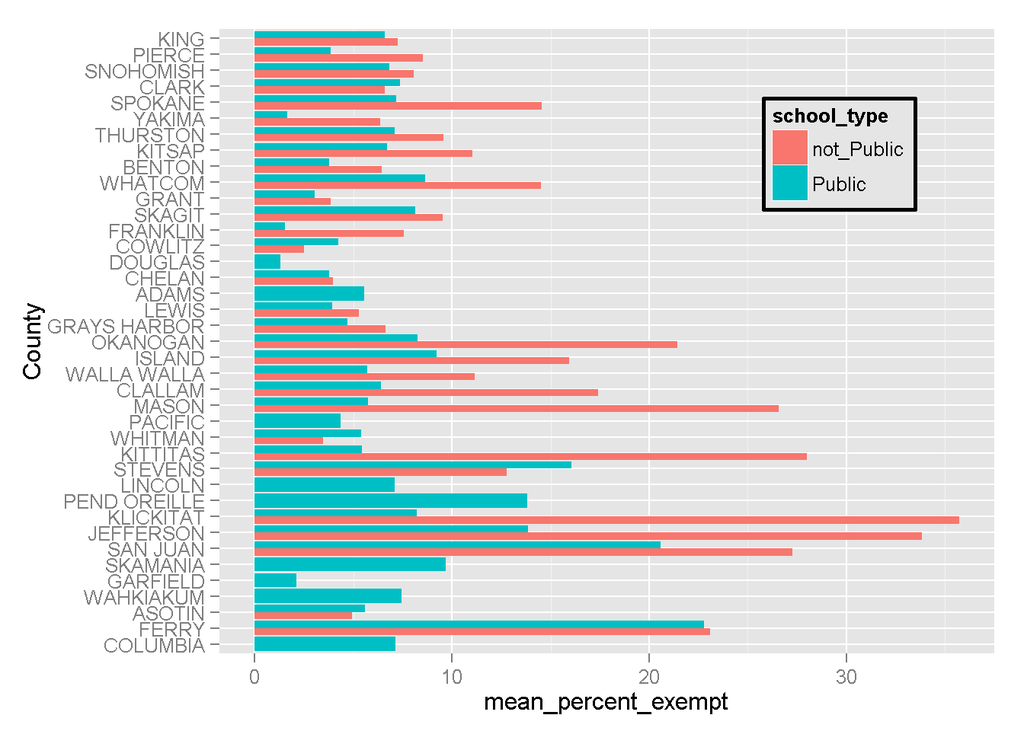

Melting the county_group dataframe for additional bar plot visualizatons. Melt is achieved by using gather() [tidyr package], where mean_percent_medical_exempt and mean_percent_nonmedexempt are gathered into exemption type, with each individual mean captured in mean_percent_exemption_type.

```
## Observations: 39
## Variables:
## $ school_county                 (chr) "KING", "PIERCE", "SNOHOMISH", "...
## $ mean_percent_medical_exempt   (dbl) 1.99, 0.72, 1.13, 0.59, 0.87, 0....
## $ median_percent_medical_exempt (dbl) 0.82, 0.52, 0.68, 0.50, 0.59, 0....
## $ max_percent_medical_exempt    (dbl) 29.63, 7.46, 12.26, 2.30, 14.29,...
## $ min_percent_medical_exempt    (dbl) 0, 0, 0, 0, 0, 0, 0, 0, 0, 0, 0,...
## $ mean_percent_exempt_MMR       (dbl) 3.51, 2.96, 4.42, 5.36, 5.50, 1....
## $ median_percent_exempt_MMR     (dbl) 2.48, 2.23, 3.30, 4.57, 3.57, 0....
## $ max_percent_exempt_MMR        (dbl) 36.50, 33.10, 32.18, 36.48, 44.9...
## $ min_percent_exempt_MMR        (dbl) 0.00, 0.00, 0.00, 0.00, 0.00, 0....
## $ mean_percent_exempt           (dbl) 6.77, 4.42, 6.96, 7.27, 8.15, 2....
## $ median_percent_exempt         (dbl) 5.03, 3.66, 5.42, 6.50, 6.03, 1....
## $ max_percent_exempt            (dbl) 43.87, 33.79, 42.70, 43.97, 44.3...
## $ min_percent_exempt            (dbl) 0.00, 0.00, 0.00, 0.00, 0.00, 0....
## $ mean_percent_nonmedexempt     (dbl) 4.99, 3.88, 5.97, 6.84, 7.30, 1....
## $ median_percent_nonmedexempt   (dbl) 3.60, 2.97, 4.66, 6.14, 5.35, 1....
## $ max_percent_nonmedexempt      (dbl) 42.86, 33.79, 37.44, 42.67, 44.3...
## $ min_percent_nonmedexempt      (dbl) 0.00, 0.00, 0.00, 0.00, 0.00, 0....
## $ schools                       (int) 581, 253, 205, 129, 165, 90, 86,...
## $ students                      (dbl) 289034, 132412, 108104, 78252, 7...
```

```
## Observations: 78
## Variables:
## $ school_county                 (chr) "KING", "PIERCE", "SNOHOMISH", "...
## $ median_percent_medical_exempt (dbl) 0.82, 0.52, 0.68, 0.50, 0.59, 0....
## $ max_percent_medical_exempt    (dbl) 29.63, 7.46, 12.26, 2.30, 14.29,...
## $ min_percent_medical_exempt    (dbl) 0, 0, 0, 0, 0, 0, 0, 0, 0, 0, 0,...
## $ mean_percent_exempt_MMR       (dbl) 3.51, 2.96, 4.42, 5.36, 5.50, 1....
## $ median_percent_exempt_MMR     (dbl) 2.48, 2.23, 3.30, 4.57, 3.57, 0....
## $ max_percent_exempt_MMR        (dbl) 36.50, 33.10, 32.18, 36.48, 44.9...
## $ min_percent_exempt_MMR        (dbl) 0.00, 0.00, 0.00, 0.00, 0.00, 0....
## $ mean_percent_exempt           (dbl) 6.77, 4.42, 6.96, 7.27, 8.15, 2....
## $ median_percent_exempt         (dbl) 5.03, 3.66, 5.42, 6.50, 6.03, 1....
## $ max_percent_exempt            (dbl) 43.87, 33.79, 42.70, 43.97, 44.3...
## $ min_percent_exempt            (dbl) 0.00, 0.00, 0.00, 0.00, 0.00, 0....
## $ median_percent_nonmedexempt   (dbl) 3.60, 2.97, 4.66, 6.14, 5.35, 1....
## $ max_percent_nonmedexempt      (dbl) 42.86, 33.79, 37.44, 42.67, 44.3...
## $ min_percent_nonmedexempt      (dbl) 0.00, 0.00, 0.00, 0.00, 0.00, 0....
## $ schools                       (int) 581, 253, 205, 129, 165, 90, 86,...
## $ students                      (dbl) 289034, 132412, 108104, 78252, 7...
## $ exemption_type                (fctr) mean_percent_medical_exempt, me...
## $ mean_percent_exemption_type   (dbl) 1.99, 0.72, 1.13, 0.59, 0.87, 0....
```

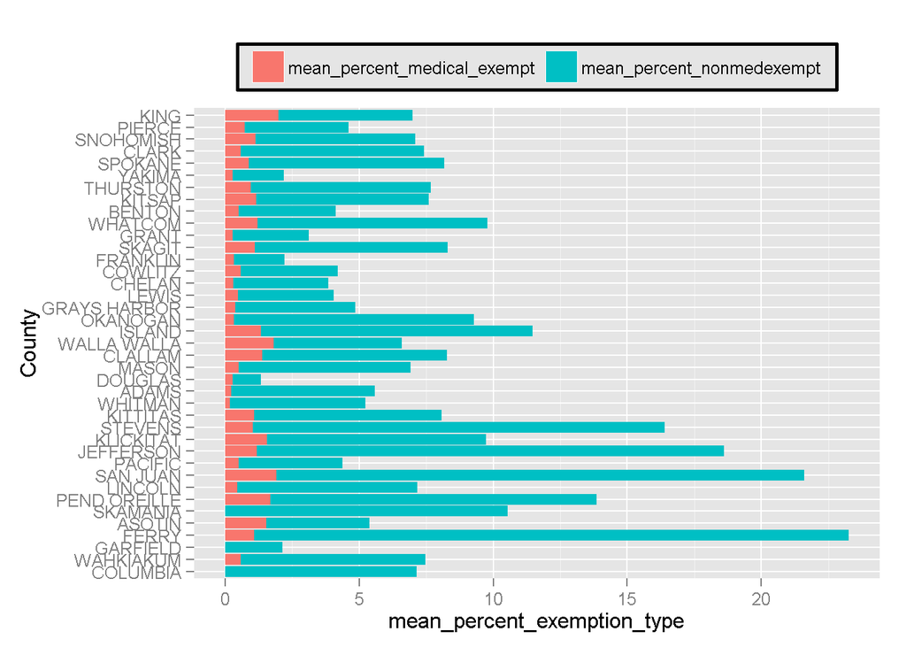

Add a quartile field into melt_county_group, as a factor.

```
##  [1] 2 2 2 3 3 1 3 3 1 4 1 3 1 1 1 1 2 4 4 2 3 2 1 2 2 3 4 4 4 1 4 2 4 4 2
## [36] 4 1 3 3 2 2 2 3 3 1 3 3 1 4 1 3 1 1 1 1 2 4 4 2 3 2 1 2 2 3 4 4 4 1 4
## [71] 2 4 4 2 4 1 3 3
## Levels: 1 2 3 4
```

```
## Observations: 78
## Variables:
## $ school_county                 (chr) "KING", "PIERCE", "SNOHOMISH", "...
## $ median_percent_medical_exempt (dbl) 0.82, 0.52, 0.68, 0.50, 0.59, 0....
## $ max_percent_medical_exempt    (dbl) 29.63, 7.46, 12.26, 2.30, 14.29,...
## $ min_percent_medical_exempt    (dbl) 0, 0, 0, 0, 0, 0, 0, 0, 0, 0, 0,...
## $ mean_percent_exempt_MMR       (dbl) 3.51, 2.96, 4.42, 5.36, 5.50, 1....
## $ median_percent_exempt_MMR     (dbl) 2.48, 2.23, 3.30, 4.57, 3.57, 0....
## $ max_percent_exempt_MMR        (dbl) 36.50, 33.10, 32.18, 36.48, 44.9...
## $ min_percent_exempt_MMR        (dbl) 0.00, 0.00, 0.00, 0.00, 0.00, 0....
## $ mean_percent_exempt           (dbl) 6.77, 4.42, 6.96, 7.27, 8.15, 2....
## $ median_percent_exempt         (dbl) 5.03, 3.66, 5.42, 6.50, 6.03, 1....
## $ max_percent_exempt            (dbl) 43.87, 33.79, 42.70, 43.97, 44.3...
## $ min_percent_exempt            (dbl) 0.00, 0.00, 0.00, 0.00, 0.00, 0....
## $ median_percent_nonmedexempt   (dbl) 3.60, 2.97, 4.66, 6.14, 5.35, 1....
## $ max_percent_nonmedexempt      (dbl) 42.86, 33.79, 37.44, 42.67, 44.3...
## $ min_percent_nonmedexempt      (dbl) 0.00, 0.00, 0.00, 0.00, 0.00, 0....
## $ schools                       (int) 581, 253, 205, 129, 165, 90, 86,...
## $ students                      (dbl) 289034, 132412, 108104, 78252, 7...
## $ exemption_type                (fctr) mean_percent_medical_exempt, me...
## $ mean_percent_exemption_type   (dbl) 1.99, 0.72, 1.13, 0.59, 0.87, 0....
## $ mean_percent_exempt_quartile  (int) 2, 2, 2, 3, 3, 1, 3, 3, 1, 4, 1,...
```

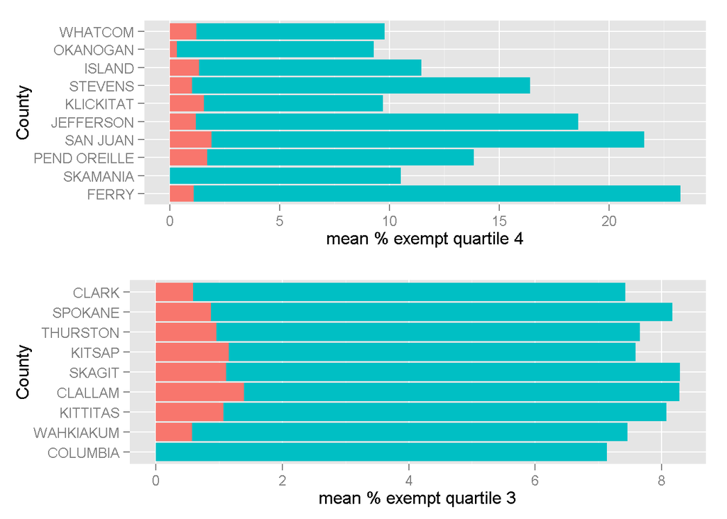

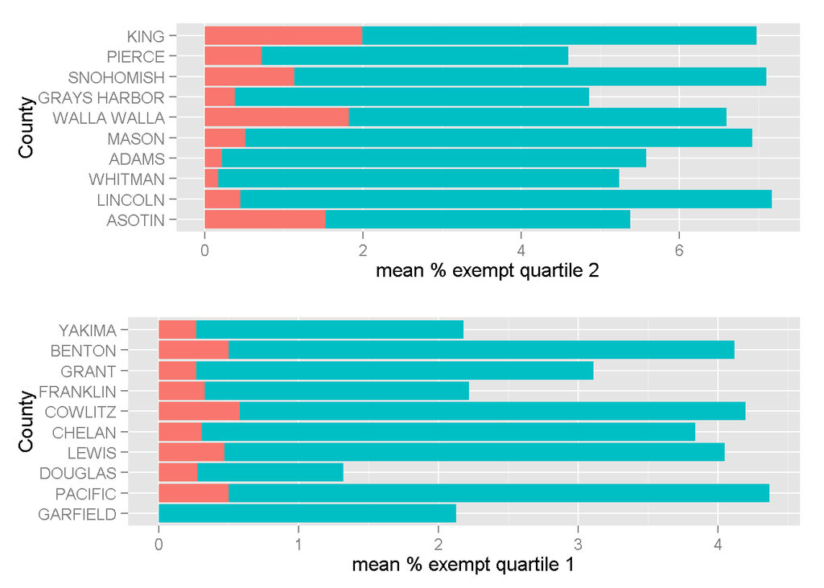

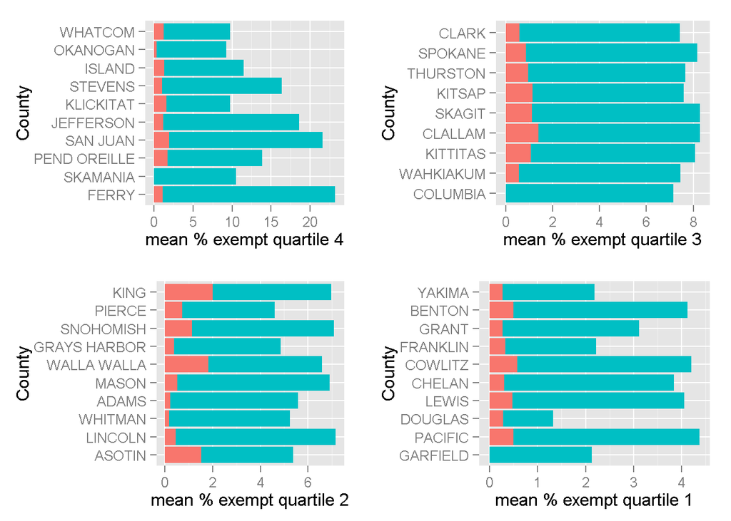

[figure not shown]

# Multivariate Analysis

### Talk about some of the relationships you observed in this part of the investigation. Were there features that strengthened each other in terms of looking at your feature(s) of interest?

I didn’t observe any relationships that stand out fromt the bivariate plots section.

### Were there any interesting or surprising interactions between features?

### OPTIONAL: Did you create any models with your dataset? Discuss the strengths and limitations of your model.

# Final Plots and Summary

# Reflection

# References

- Udacity Forums and Coaches Lounge*
- [Hadley Wikhams Tidy Data manuscript and associate vignette](https://github.com/hadley/tidy-data)*
- [Quick R](http://www.statmethods.net/)*
- R for Dummies*
- [Cookbook for R](http://www.cookbook-r.com/)*
- R Cookbook by Paul Teetor (O’Reilly)*
- [Kieran Healy’s Github Repo](https://github.com/kjhealy/vaccines-ca/blob/master/vaccines.r)*
- Stack Overflow*